# Phase 5 — Hydrogel rheology and printing-context exploratory analysis

This notebook is Phase 5 of the **Open Materials Data Pipeline for Hydrogel Bioink Design** project.

Phase 5 uses the verified Phase 4 evidence layer to ask a narrower and more useful question:

> What descriptive rheology and image-metadata patterns can be explored without turning candidate filename relationships into confirmed physical-sample, formulation, printing-run or image links?

This is an exploratory analysis checkpoint, not a machine-learning checkpoint. The purpose is to create interpretable summaries and figures while preserving the scientific limits established in Phases 1–4.

The notebook is designed for a fresh Jupyter session:

1. save the notebook;
2. close Jupyter;
3. reopen the notebook later;
4. select the documented Python kernel;
5. choose **Restart Kernel**;
6. choose **Run All Cells**;
7. expect the full workflow to run from top to bottom without hidden state.

**Extended visualisation edition:** keeps the original seven plots and adds a worksheet-level, QC-aware, rheology-mechanics and image-metadata visualisation atlas. Outputs appear inline and are saved as PNG files in `data/processed/hydrogel_rheology_and_printing_context_analysis/figures/`.

**Kernel setup:** from the selected Jupyter kernel run `%pip install -r requirements-phase5.txt` (if in the project root), then **Restart Kernel → Run All Cells**. Do not use an unrelated `polymer-tg` kernel. See the accompanying Phase 5 guide for Windows steps.

**Important for Windows/Anaconda:** Phase 5 v3 saves all 25 PNG figures but displays only four inline previews. Browse `data/processed/hydrogel_rheology_and_printing_context_analysis/phase5_figure_gallery.html` to see all visualisations. If a run remains Busy, check `phase5_execution_progress.log` in that directory. The last `SECTION START` or `FIGURE START` without a matching `FINISHED` line locates the blockage. No package manager runs during `Run All`.

**v4 environment fix:** The screenshot of the Windows `hydrogel-bioink` kernel shows that Matplotlib is absent. The pre-flight below attempts to install **only missing Matplotlib** with the Python interpreter running this notebook. The installer is bounded (150 seconds), prints progress and saves a local installer log; when Matplotlib is already installed, it makes no package-manager calls. It then tests headless figure rendering. If installation cannot finish (e.g. blocked internet or corporate proxy), a short manual Anaconda Prompt command is given instead of an unbounded Busy kernel. Your original scientific analysis, 25 PNG figures and four inline previews are retained.

## Scientific boundaries for Phase 5

The Phase 4 outputs made the analysis possible, but they did not solve every scientific problem. Phase 5 therefore follows these rules:

- Rheology points are treated as measurement points nested inside worksheets, not as independent formulations.
- Filename-stem matching is treated as candidate evidence only, not as confirmed physical sample identity.
- The source token `mPas` remains unresolved. Apparent viscosity is plotted in its source token rather than converted to Pa·s.
- Image metadata can be summarised, but the actual image pixels are not inspected in this phase.
- Shape labels, ink labels, irradiation intensity and SPS annotations are metadata fields, not automatically print-quality labels.
- No predictive model, target label or training set is created here.
- QC warnings are retained and reported rather than silently removed.

This sounds strict, but it is the useful kind of strict. It stops a pretty plot from quietly becoming a claim the source data never earned.

## Data-science and polymer concepts used in this notebook

**Exploratory data analysis** describes distributions, ranges, missingness, grouping structure and possible patterns. It does not by itself prove causation or prediction readiness.

**Measurement hierarchy** matters because a rheology curve contains repeated points from one acquisition. Treating every point as an independent material would inflate the apparent amount of evidence.

**Record linkage** remains a source of uncertainty. A software join or matched filename can support review, but it is not the same as a verified material history.

**Hydrogel rheology** needs measurement context. Viscosity depends on shear rate and may show shear-thinning. Storage modulus `G′` and loss modulus `G″` describe elastic and viscous contributions under oscillatory test conditions. These quantities should be interpreted with strain, frequency, temperature and acquisition context attached.

**Printing context** is broader than rheology. Nozzle geometry, pressure, speed, crosslinking, construct design, irradiation, and image quality can matter. This dataset has some image metadata, but Phase 5 does not claim a validated printability target.

## Start-up verification — install missing Matplotlib into the active kernel (v4)

This step addresses the error reported on Windows: `Missing Python packages in this selected Jupyter kernel: matplotlib`. It uses `sys.executable` to ensure that installation targets the Python interpreter **actually running the notebook**, not another Python installation.

- If Matplotlib is already installed and importable, nothing is installed.
- If Matplotlib is absent, the notebook attempts a **single bounded binary-wheel installation** using pip; it does **not** launch conda or wait indefinitely. Progress is printed and the installation log is saved.
- If installation cannot be completed, the notebook stops with manual **Anaconda Prompt** instructions rather than silently skipping any graphs.
- After installation, a tiny rendering test verifies that Matplotlib can generate PNG output using the non-interactive `Agg` backend.

> **Important:** First-time installation needs internet access. The automated bootstrap cannot guarantee that a corporate firewall, proxy, locked-down environment or unsupported Python version will allow the installation. The one-time Anaconda Prompt alternative is in the accompanying guide.

```python
# Phase 5 v4: bounded, kernel-specific Matplotlib installation + real render test.
# Does not run conda; does not reinstall packages that can already be imported.
# Do not copy this cell to unrelated environments without reviewing the dependency policy.
import importlib
import importlib.util
import os
import subprocess
import sys
import tempfile
import time
from pathlib import Path

ACTIVE_PYTHON = Path(sys.executable).resolve()
print('Selected Jupyter Python interpreter:', ACTIVE_PYTHON, flush=True)
print('Matplotlib setup: detecting packages.', flush=True)

# Select headless plotting BEFORE any import of matplotlib.pyplot.
os.environ['MPLBACKEND'] = 'Agg'

CORE_REQUIREMENTS = ('numpy', 'pandas', 'IPython')
missing_core = [p for p in CORE_REQUIREMENTS if importlib.util.find_spec(p) is None]
if missing_core:
    raise RuntimeError(
        'Core packages missing from the selected kernel: ' + ', '.join(missing_core) + '\n'
        'Use Anaconda Prompt to run:\n'
        '  conda activate hydrogel-bioink\n'
        '  conda install -c conda-forge numpy pandas ipython ipykernel matplotlib\n'
        'Restart the kernel before running all cells again.'
    )

# This is the only automatic package installation the notebook will attempt.
if importlib.util.find_spec('matplotlib') is None:
    if importlib.util.find_spec('pip') is None:
        raise RuntimeError(
            'Matplotlib and pip are both missing from the active Jupyter interpreter.\n'
            'Use Anaconda Prompt: conda activate hydrogel-bioink\n'
            'conda install -c conda-forge matplotlib\n'
            'Then restart the kernel and Run All.'
        )
    # Avoid writing the log to a protected or unavailable project directory.
    try:
        INSTALL_LOG = Path.cwd() / 'phase5_matplotlib_install.log'
        with INSTALL_LOG.open('w', encoding='utf-8') as handle:
            handle.write('Phase 5 Matplotlib installation log\n')
    except OSError:
        INSTALL_LOG = Path(tempfile.gettempdir()) / 'phase5_matplotlib_install.log'

    install_command = [
        str(ACTIVE_PYTHON), '-m', 'pip', 'install',
        '--disable-pip-version-check', '--no-input', '--only-binary=:all:',
        '--retries', '1', '--timeout', '15', 'matplotlib',
    ]
    print('Matplotlib missing; attempting a ONE-TIME installation in this kernel.', flush=True)
    print('Installation log:', INSTALL_LOG, flush=True)
    MAX_INSTALL_SECONDS = 150
    start_install = time.monotonic()
    exit_code = None
    next_report = 15
    with INSTALL_LOG.open('a', encoding='utf-8') as install_output:
        try:
            child = subprocess.Popen(install_command, stdout=install_output,
                                     stderr=subprocess.STDOUT, stdin=subprocess.DEVNULL)
        except OSError as exc:
            raise RuntimeError(
                f'Cannot launch pip from {ACTIVE_PYTHON}: {exc}\n'
                'In Anaconda Prompt run: conda activate hydrogel-bioink\n'
                'conda install -c conda-forge matplotlib'
            ) from exc
        while True:
            exit_code = child.poll()
            if exit_code is not None:
                break
            elapsed_install = time.monotonic() - start_install
            if elapsed_install >= MAX_INSTALL_SECONDS:
                child.kill()
                child.wait()
                tail = INSTALL_LOG.read_text(encoding='utf-8', errors='replace')[-2000:]
                raise RuntimeError(
                    'Matplotlib pip installation exceeded 150 seconds and was stopped.\n'
                    f'Log: {INSTALL_LOG}\nLast pip messages:\n{tail}\n'
                    'Use Anaconda Prompt outside Jupyter:\n'
                    '  conda activate hydrogel-bioink\n'
                    '  conda install -c conda-forge matplotlib\n'
                    'Restart the kernel and Run All afterward.'
                )
            # Keep the notebook visibly alive; do not present a silent Busy kernel.
            if elapsed_install >= next_report:
                print(f'Matplotlib installation in progress: {elapsed_install:.0f}s / {MAX_INSTALL_SECONDS}s', flush=True)
                next_report += 15
            time.sleep(1.0)

    install_details = INSTALL_LOG.read_text(encoding='utf-8', errors='replace')
    if exit_code != 0:
        raise RuntimeError(
            f'Matplotlib installation failed (pip exit code {exit_code}).\n'
            f'Installation log: {INSTALL_LOG}\n'
            f'Last installer messages:\n{install_details[-2500:]}\n'
            'Use Anaconda Prompt instead:\n'
            '  conda activate hydrogel-bioink\n'
            '  conda install -c conda-forge matplotlib\n'
            'Then restart the Jupyter kernel and Run All.'
        )
    importlib.invalidate_caches()
    print('Matplotlib installation completed. Verifying imports and PNG renderer.', flush=True)
else:
    print('Matplotlib found: no package installation required.', flush=True)

try:
    import numpy as _np_preflight
    import pandas as _pd_preflight
    import matplotlib as _matplotlib_preflight
    _matplotlib_preflight.use('Agg', force=True)
    from matplotlib.figure import Figure as _FigurePreflight
    from matplotlib.backends.backend_agg import FigureCanvasAgg as _AggCanvasPreflight
    _probe = _FigurePreflight(figsize=(1.2, 0.9), dpi=72)
    _axis = _probe.subplots()
    _axis.plot([0, 1], [0, 1])
    _AggCanvasPreflight(_probe).draw()
    _probe.clear()
except Exception as exc:
    raise RuntimeError(
        'Matplotlib import / PNG rendering verification failed in the selected kernel.\n'
        f'Interpreter: {ACTIVE_PYTHON}\n'
        f'Problem: {type(exc).__name__}: {exc}\n'
        'Try this in Anaconda Prompt (outside Jupyter):\n'
        '  conda activate hydrogel-bioink\n'
        '  conda install -c conda-forge matplotlib\n'
        'Then Restart Kernel and Run All.'
    ) from exc

print('Dependency and Matplotlib rendering check: PASS.', flush=True)
print('NumPy:', _np_preflight.__version__, '| pandas:', _pd_preflight.__version__,
      '| Matplotlib:', _matplotlib_preflight.__version__, flush=True)
```

```
Selected Jupyter Python interpreter: C:\Users\sufer\anaconda3\envs\hydrogel-bioink\python.exe
Matplotlib setup: detecting packages.
Matplotlib found: no package installation required.
Dependency and Matplotlib rendering check: PASS.
NumPy: 2.5.3 | pandas: 2.2.3 | Matplotlib: 3.11.2
```

```python
# Phase 5 dependencies and reproducible root detection
# Use the documented `hydrogel-bioink` Jupyter kernel (see requirements-phase5.txt).
from __future__ import annotations
import hashlib
import json
import math
import os
import platform
import re
import sys
from datetime import datetime, timezone
from pathlib import Path
from typing import Any, Dict, Iterable, List, Optional, Tuple

import numpy as np
import pandas as pd

# Resolve the project from the current directory, its parents, or an explicit override.
# This supports launching Jupyter from the project root OR the notebooks/ directory.
def resolve_project_root() -> Path:
    override = os.environ.get('HYDROGEL_PROJECT_ROOT', '').strip()
    starts = [Path(override).expanduser().resolve()] if override else []
    starts.append(Path.cwd().resolve())
    checked = []
    for start in starts:
        for root in [start, *start.parents]:
            folder = root / 'data' / 'processed' / 'record_linkage_and_analysis_ready_evidence_layer'
            checked.append(str(folder))
            if (folder / 'phase4_run_manifest.json').is_file() and (folder / 'measurement_point_linkage_layer.csv').is_file():
                return root
    raise FileNotFoundError(
        'Cannot find the persisted Phase 4 evidence layer. Launch Jupyter in the hydrogel-bioink '
        'project root or a subfolder, or set HYDROGEL_PROJECT_ROOT to its full path. '
        'Looked for data/processed/record_linkage_and_analysis_ready_evidence_layer. '
        f'Checked: {checked[:8]}')

PROJECT_ROOT = resolve_project_root()
PHASE4_DIR = PROJECT_ROOT / 'data' / 'processed' / 'record_linkage_and_analysis_ready_evidence_layer'
PHASE5_DIR = PROJECT_ROOT / 'data' / 'processed' / 'hydrogel_rheology_and_printing_context_analysis'
FIGURE_DIR = PHASE5_DIR / 'figures'
PHASE5_DIR.mkdir(parents=True, exist_ok=True)
FIGURE_DIR.mkdir(parents=True, exist_ok=True)
os.environ.setdefault('MPLCONFIGDIR', str(PROJECT_ROOT / '.matplotlib_cache'))
Path(os.environ['MPLCONFIGDIR']).mkdir(parents=True, exist_ok=True)

try:
    import matplotlib
    # No browser/Qt GUI dependency; render figures deterministically to PNG.
    matplotlib.use('Agg')
    import matplotlib.pyplot as plt
    from IPython.display import display, Image, Markdown
except (ImportError, OSError) as exc:
    raise RuntimeError(
        "Core packages were detected but one failed during plotting initialisation. "
        "Confirm that the above dependency check passed in this kernel, then Restart Kernel "
        "and Run All. For conda, activate hydrogel-bioink and run: "
        "conda install -c conda-forge matplotlib numpy pandas ipython ipykernel. "
        f"The active interpreter is {sys.executable}."
    ) from exc

pd.set_option('display.max_columns', 120)
pd.set_option('display.width', 180)
pd.set_option('display.max_colwidth', 120)
plt.ioff()
plt.rcParams.update({'figure.dpi': 110, 'savefig.dpi': 160, 'axes.grid': False,
                     'font.size': 10, 'axes.titlesize': 12, 'figure.max_open_warning': 30})
RUN_UTC = datetime.now(timezone.utc).isoformat()
print('Project directory:', PROJECT_ROOT.name)
print('Phase 4 input folder (relative):', PHASE4_DIR.relative_to(PROJECT_ROOT))
print('Phase 5 output folder (relative):', PHASE5_DIR.relative_to(PROJECT_ROOT))
print('Python:', sys.version.split()[0], '| pandas:',pd.__version__,
      '| NumPy:',np.__version__, '| matplotlib:',matplotlib.__version__)

print('Execution will write phase5_execution_progress.log in the Phase 5 output folder.',flush=True)
```

```
Project directory: hydrogel-bioink
Phase 4 input folder (relative): data\processed\record_linkage_and_analysis_ready_evidence_layer
Phase 5 output folder (relative): data\processed\hydrogel_rheology_and_printing_context_analysis
Python: 3.12.15 | pandas: 2.2.3 | NumPy: 2.5.3 | matplotlib: 3.11.2
Execution will write phase5_execution_progress.log in the Phase 5 output folder.
```

## Helper functions

The helper functions below keep the notebook deterministic and restart-safe.

The most important principle is **explicit input resolution**. The notebook does not assume that a variable exists from an earlier Jupyter session. It checks that the required Phase 4 files are present, records their sizes and hashes, then uses those verified files for analysis.

```python
def sha256_file(path: Path, block_size: int = 1024 * 1024) -> str:
    digest = hashlib.sha256()
    with path.open("rb") as handle:
        for block in iter(lambda: handle.read(block_size), b""):
            digest.update(block)
    return digest.hexdigest()


def file_record(path: Path, role: str) -> Dict[str, Any]:
    return {
        "canonical_filename": path.name,
        "relative_path": str(path.relative_to(PROJECT_ROOT)) if path.exists() else "",
        "role": role,
        "exists": path.exists(),
        "file_size_bytes": path.stat().st_size if path.exists() else None,
        "sha256": sha256_file(path) if path.exists() else None,
        "status": "RESOLVED" if path.exists() else "MISSING",
    }


def require_columns(df: pd.DataFrame, required: Iterable[str], table_name: str) -> List[Dict[str, Any]]:
    records = []
    for col in required:
        ok = col in df.columns
        records.append({
            "check": f"{table_name} has column {col}",
            "status": "PASS" if ok else "FAIL",
            "severity": "CRITICAL",
            "evidence": json.dumps({"column": col, "present": ok}),
        })
    return records


def safe_divide(num: pd.Series, den: pd.Series) -> pd.Series:
    num = pd.to_numeric(num, errors="coerce")
    den = pd.to_numeric(den, errors="coerce")
    return num.where(den != 0) / den.where(den != 0)


def loglog_slope(x: pd.Series, y: pd.Series) -> float:
    x = pd.to_numeric(x, errors="coerce")
    y = pd.to_numeric(y, errors="coerce")
    mask = (x > 0) & (y > 0) & np.isfinite(x) & np.isfinite(y)
    if int(mask.sum()) < 3:
        return np.nan
    lx = np.log10(x[mask].astype(float))
    ly = np.log10(y[mask].astype(float))
    if lx.nunique() < 2:
        return np.nan
    slope, _ = np.polyfit(lx, ly, 1)
    return float(slope)


def slope_label(slope: float) -> str:
    if pd.isna(slope):
        return "insufficient_positive_points"
    if slope < -0.15:
        return "screen_consistent_with_shear_thinning"
    if slope > 0.15:
        return "screen_consistent_with_viscosity_increase"
    return "screen_near_flat_on_loglog_axes"


def parse_rheology_source_label(source_stem: Any) -> Dict[str, Any]:
    """Extract candidate label information from rheology filename stems.

    These fields are source-label descriptors only. They are not validated formulation entities.
    """
    text = "" if pd.isna(source_stem) else str(source_stem)
    alg = re.search(r"ALG[^_]*?(?:-I1G)?-?Ph_(\d+(?:\.\d+)?)", text)
    ha = re.search(r"HA[^_]*?-?Ph_(\d+(?:\.\d+)?)", text)
    temp = re.search(r"_(\d+(?:\.\d+)?)C(?:_|$)", text)
    replicate = re.search(r"_(\d+)$", text)
    return {
        "source_stem": text,
        "candidate_alg_ph_label": float(alg.group(1)) if alg else np.nan,
        "candidate_ha_ph_label": float(ha.group(1)) if ha else np.nan,
        "candidate_temperature_c_label": float(temp.group(1)) if temp else np.nan,
        "candidate_file_index_label": int(replicate.group(1)) if replicate else np.nan,
        "descriptor_status": "source_label_descriptor_only_not_validated_formulation",
    }


def write_csv(df: pd.DataFrame, filename: str) -> Path:
    path = PHASE5_DIR / filename
    df.to_csv(path, index=False)
    return path


PROGRESS_LOG = PHASE5_DIR / 'phase5_execution_progress.log'
PROGRESS_LOG.write_text('Phase 5 progress log — new clean-kernel run\n',encoding='utf-8')

def phase5_progress(message: str) -> None:
    from datetime import datetime, timezone
    stamp = datetime.now(timezone.utc).strftime('%Y-%m-%d %H:%M:%S UTC')
    line=f'[{stamp}] {message}'
    with PROGRESS_LOG.open('a',encoding='utf-8') as fp:
        fp.write(line+'\n')
        fp.flush()
    print(line,flush=True)

def save_figure(fig: plt.Figure, filename: str) -> Path:
    """Save figures, close the Matplotlib object, but do NOT embed 25 full PNGs in the
    live Jupyter document. Rendering 25 embedded images can overload Jupyter's
    browser and make its progress indicator appear stuck on Windows.
    The PNG files are preserved, and a gallery is generated at the end.
    """
    path=FIGURE_DIR / filename
    phase5_progress('FIGURE START: '+filename)
    try:
        fig.savefig(path,dpi=145,bbox_inches='tight',facecolor='white')
    finally:
        plt.close(fig)
    phase5_progress('FIGURE FINISHED: '+filename+' | '+str(path.stat().st_size)+' bytes')
    return path

def row_count(path: Path) -> Optional[int]:
    if not path.exists() or path.suffix.lower() != ".csv":
        return None
    return sum(1 for _ in path.open("r", encoding="utf-8")) - 1

phase5_progress("PROGRESS LOG READY; subsequent cells report start and finish")
```

```
[2026-10-10 01:36:07 UTC] PROGRESS LOG READY; subsequent cells report start and finish
```

## Resolve and load Phase 4 inputs

Phase 5 reads the Phase 4 outputs rather than going back to raw Excel workbooks. This is intentional. Phase 4 already created the evidence layer and documented what can be joined safely.

The input-resolution table produced here is a Phase 5 audit trail: it records which Phase 4 files were used, their paths, sizes and SHA-256 hashes.

```python
phase5_progress("SECTION START: load Phase 4 evidence")
required_inputs = {
    "linked_measurement_evidence_layer.csv": "phase4_linked_measurement_evidence",
    "measurement_point_linkage_layer.csv": "phase4_measurement_point_linkage",
    "image_metadata_linkage_layer.csv": "phase4_image_metadata_linkage",
    "candidate_rheology_image_linkage.csv": "phase4_candidate_filename_linkage",
    "qc_linkage_summary.csv": "phase4_qc_context",
    "analysis_readiness_summary.csv": "phase4_analysis_readiness",
    "unresolved_linkage_review_items.csv": "phase4_unresolved_review_items",
    "phase4_validation_summary.csv": "phase4_validation_ledger",
    "phase4_data_dictionary.csv": "phase4_data_dictionary",
    "phase4_run_manifest.json": "phase4_run_manifest",
}

input_records = [file_record(PHASE4_DIR / filename, role) for filename, role in required_inputs.items()]
input_resolution = pd.DataFrame(input_records)
input_resolution_path = write_csv(input_resolution, "phase5_input_file_resolution.csv")

display(input_resolution)

missing = input_resolution.loc[input_resolution["status"] != "RESOLVED", "canonical_filename"].tolist()
if missing:
    raise FileNotFoundError(f"Missing required Phase 4 inputs: {missing}")

linked = pd.read_csv(PHASE4_DIR / "linked_measurement_evidence_layer.csv")
points = pd.read_csv(PHASE4_DIR / "measurement_point_linkage_layer.csv")
images = pd.read_csv(PHASE4_DIR / "image_metadata_linkage_layer.csv")
candidates = pd.read_csv(PHASE4_DIR / "candidate_rheology_image_linkage.csv")
qc = pd.read_csv(PHASE4_DIR / "qc_linkage_summary.csv")
readiness = pd.read_csv(PHASE4_DIR / "analysis_readiness_summary.csv")
unresolved = pd.read_csv(PHASE4_DIR / "unresolved_linkage_review_items.csv")
phase4_validation = pd.read_csv(PHASE4_DIR / "phase4_validation_summary.csv")
phase4_dictionary = pd.read_csv(PHASE4_DIR / "phase4_data_dictionary.csv")
phase4_manifest = json.loads((PHASE4_DIR / "phase4_run_manifest.json").read_text(encoding="utf-8"))

print("Loaded rows:")
print("linked measurement evidence:", len(linked))
print("measurement points:", len(points))
print("image metadata:", len(images))
print("candidate linkage rows:", len(candidates))
print("QC findings:", len(qc))
print("unresolved review items:", len(unresolved))

phase5_progress("SECTION FINISHED: load Phase 4 evidence")
```

```
[2026-10-10 01:36:07 UTC] SECTION START: load Phase 4 evidence
```

|  | canonical_filename | relative_path | role | exists | file_size_bytes | sha256 | status |
| --- | --- | --- | --- | --- | --- | --- | --- |
| 0 | linked_measurement_evidence_layer.csv | data\processed\record_linkage_and_analysis_ready_evidence_layer\linked_measurement_evidence_layer.csv | phase4_linked_measurement_evidence | True | 40656017 | 83e852547a1817ffc56b489807e0056ddcca19f691b9a059742869799cc916dd | RESOLVED |
| 1 | measurement_point_linkage_layer.csv | data\processed\record_linkage_and_analysis_ready_evidence_layer\measurement_point_linkage_layer.csv | phase4_measurement_point_linkage | True | 4051549 | 99536b827b53ef80a8307dfb611b3cbabc7f85aa3db795814789d3caa20685f6 | RESOLVED |
| 2 | image_metadata_linkage_layer.csv | data\processed\record_linkage_and_analysis_ready_evidence_layer\image_metadata_linkage_layer.csv | phase4_image_metadata_linkage | True | 549169 | d9155262e0126c0dbaf0b916b53148298969a9ba729c2ab9d30b547604beea5d | RESOLVED |
| 3 | candidate_rheology_image_linkage.csv | data\processed\record_linkage_and_analysis_ready_evidence_layer\candidate_rheology_image_linkage.csv | phase4_candidate_filename_linkage | True | 22937 | f6314d467ccf0c516d08475d287b1a9e94b430f025ea1f584227049d41e58e42 | RESOLVED |
| 4 | qc_linkage_summary.csv | data\processed\record_linkage_and_analysis_ready_evidence_layer\qc_linkage_summary.csv | phase4_qc_context | True | 8779 | 116548169a6f849aef82b48753f493ce2ca03a5d171b7f12e1d0f9106b4a6671 | RESOLVED |
| 5 | analysis_readiness_summary.csv | data\processed\record_linkage_and_analysis_ready_evidence_layer\analysis_readiness_summary.csv | phase4_analysis_readiness | True | 1763 | cdd36898a18fa44b50a394ac0c22d3371cc54677a93a0647c1d571e19dcb406a | RESOLVED |
| 6 | unresolved_linkage_review_items.csv | data\processed\record_linkage_and_analysis_ready_evidence_layer\unresolved_linkage_review_items.csv | phase4_unresolved_review_items | True | 2810 | a6ac675bf398343b459e19bc99563e618bd2ccee3d172dd87161261b5d779ec4 | RESOLVED |
| 7 | phase4_validation_summary.csv | data\processed\record_linkage_and_analysis_ready_evidence_layer\phase4_validation_summary.csv | phase4_validation_ledger | True | 3789 | 34e65e2e7449b9ec02cdc42cefca5dc65d8b797f74331d8567cd20232e559d38 | RESOLVED |
| 8 | phase4_data_dictionary.csv | data\processed\record_linkage_and_analysis_ready_evidence_layer\phase4_data_dictionary.csv | phase4_data_dictionary | True | 23027 | 7ee53a1591586ce69bc04e4d98c5058e2d0e39f49301082191d23e5fe91b3c8a | RESOLVED |
| 9 | phase4_run_manifest.json | data\processed\record_linkage_and_analysis_ready_evidence_layer\phase4_run_manifest.json | phase4_run_manifest | True | 21385 | c7e5760997a72afc9f338b89f73aa496d6897ec85c383680a615e8747644b0a9 | RESOLVED |

```
Loaded rows:
linked measurement evidence: 39100
measurement points: 4600
image metadata: 1031
candidate linkage rows: 62
QC findings: 25
unresolved review items: 11
[2026-10-10 01:36:08 UTC] SECTION FINISHED: load Phase 4 evidence
```

## Validate Phase 5 input contracts

Before plotting, the notebook checks the fields it depends on. This keeps Phase 5 honest: if a future Phase 4 output changes shape, the notebook should fail early with a clear reason rather than quietly producing misleading figures.

```python
phase5_progress("SECTION START: validate Phase 4 input contracts")
validation_records: List[Dict[str, Any]] = []

validation_records.extend(require_columns(points, [
    "member_path", "sheet", "source_excel_row", "measurement_family", "measurement_point_key", "worksheet_key", "source_stem",
    "shear_rate_per_s", "apparent_viscosity_source", "storage_modulus_pa", "loss_modulus_pa", "strain_fraction",
    "frequency_hz", "temperature_c", "phase4_linkage_status", "confirmed_physical_sample_link", "point_qc_finding_ids",
], "measurement_point_linkage_layer.csv"))

validation_records.extend(require_columns(images, [
    "image_id", "date_iso", "ink_type_ph", "shape", "intensity", "completeness_sam", "contain_sps",
    "expected_filename", "image_file_audit_status", "rheology_linkage_status", "phase4_use_status",
], "image_metadata_linkage_layer.csv"))

validation_records.extend(require_columns(candidates, [
    "source_stem", "GG_count", "viscosity_count", "exact_one_each_bool", "confirmed_physical_sample_link", "image_linkage_status", "phase4_caution",
], "candidate_rheology_image_linkage.csv"))

expected_counts = phase4_manifest.get("output_row_counts", {})
count_checks = {
    "linked_measurement_evidence_layer.csv": (len(linked), expected_counts.get("linked_measurement_evidence_layer.csv")),
    "measurement_point_linkage_layer.csv": (len(points), expected_counts.get("measurement_point_linkage_layer.csv")),
    "image_metadata_linkage_layer.csv": (len(images), expected_counts.get("image_metadata_linkage_layer.csv")),
    "candidate_rheology_image_linkage.csv": (len(candidates), expected_counts.get("candidate_rheology_image_linkage.csv")),
}
for name, (observed, expected) in count_checks.items():
    ok = observed == expected
    validation_records.append({
        "check": f"{name} row count matches Phase 4 manifest",
        "status": "PASS" if ok else "FAIL",
        "severity": "CRITICAL",
        "evidence": json.dumps({"observed": int(observed), "expected": None if expected is None else int(expected)}),
    })

critical_phase4_failures = int(phase4_manifest.get("critical_validation_failures", -1))
validation_records.append({
    "check": "Phase 4 manifest reports zero critical validation failures",
    "status": "PASS" if critical_phase4_failures == 0 else "FAIL",
    "severity": "CRITICAL",
    "evidence": json.dumps({"critical_validation_failures": critical_phase4_failures}),
})

phase5_validation = pd.DataFrame(validation_records)
display(phase5_validation)

if ((phase5_validation["severity"] == "CRITICAL") & (phase5_validation["status"] != "PASS")).any():
    raise RuntimeError("Critical Phase 5 validation check failed. Review phase5_validation_summary.csv for details.")

phase5_progress("SECTION FINISHED: validate Phase 4 input contracts")
```

```
[2026-10-10 01:36:08 UTC] SECTION START: validate Phase 4 input contracts
```

|  | check | status | severity | evidence |
| --- | --- | --- | --- | --- |
| 0 | measurement_point_linkage_layer.csv has column member_path | PASS | CRITICAL | {"column": "member_path", "present": true} |
| 1 | measurement_point_linkage_layer.csv has column sheet | PASS | CRITICAL | {"column": "sheet", "present": true} |
| 2 | measurement_point_linkage_layer.csv has column source_excel_row | PASS | CRITICAL | {"column": "source_excel_row", "present": true} |
| 3 | measurement_point_linkage_layer.csv has column measurement_family | PASS | CRITICAL | {"column": "measurement_family", "present": true} |
| 4 | measurement_point_linkage_layer.csv has column measurement_point_key | PASS | CRITICAL | {"column": "measurement_point_key", "present": true} |
| 5 | measurement_point_linkage_layer.csv has column worksheet_key | PASS | CRITICAL | {"column": "worksheet_key", "present": true} |
| 6 | measurement_point_linkage_layer.csv has column source_stem | PASS | CRITICAL | {"column": "source_stem", "present": true} |
| 7 | measurement_point_linkage_layer.csv has column shear_rate_per_s | PASS | CRITICAL | {"column": "shear_rate_per_s", "present": true} |
| 8 | measurement_point_linkage_layer.csv has column apparent_viscosity_source | PASS | CRITICAL | {"column": "apparent_viscosity_source", "present": true} |
| 9 | measurement_point_linkage_layer.csv has column storage_modulus_pa | PASS | CRITICAL | {"column": "storage_modulus_pa", "present": true} |
| 10 | measurement_point_linkage_layer.csv has column loss_modulus_pa | PASS | CRITICAL | {"column": "loss_modulus_pa", "present": true} |
| 11 | measurement_point_linkage_layer.csv has column strain_fraction | PASS | CRITICAL | {"column": "strain_fraction", "present": true} |
| 12 | measurement_point_linkage_layer.csv has column frequency_hz | PASS | CRITICAL | {"column": "frequency_hz", "present": true} |
| 13 | measurement_point_linkage_layer.csv has column temperature_c | PASS | CRITICAL | {"column": "temperature_c", "present": true} |
| 14 | measurement_point_linkage_layer.csv has column phase4_linkage_status | PASS | CRITICAL | {"column": "phase4_linkage_status", "present": true} |
| 15 | measurement_point_linkage_layer.csv has column confirmed_physical_sample_link | PASS | CRITICAL | {"column": "confirmed_physical_sample_link", "present": true} |
| 16 | measurement_point_linkage_layer.csv has column point_qc_finding_ids | PASS | CRITICAL | {"column": "point_qc_finding_ids", "present": true} |
| 17 | image_metadata_linkage_layer.csv has column image_id | PASS | CRITICAL | {"column": "image_id", "present": true} |
| 18 | image_metadata_linkage_layer.csv has column date_iso | PASS | CRITICAL | {"column": "date_iso", "present": true} |
| 19 | image_metadata_linkage_layer.csv has column ink_type_ph | PASS | CRITICAL | {"column": "ink_type_ph", "present": true} |
| 20 | image_metadata_linkage_layer.csv has column shape | PASS | CRITICAL | {"column": "shape", "present": true} |
| 21 | image_metadata_linkage_layer.csv has column intensity | PASS | CRITICAL | {"column": "intensity", "present": true} |
| 22 | image_metadata_linkage_layer.csv has column completeness_sam | PASS | CRITICAL | {"column": "completeness_sam", "present": true} |
| 23 | image_metadata_linkage_layer.csv has column contain_sps | PASS | CRITICAL | {"column": "contain_sps", "present": true} |
| 24 | image_metadata_linkage_layer.csv has column expected_filename | PASS | CRITICAL | {"column": "expected_filename", "present": true} |
| 25 | image_metadata_linkage_layer.csv has column image_file_audit_status | PASS | CRITICAL | {"column": "image_file_audit_status", "present": true} |
| 26 | image_metadata_linkage_layer.csv has column rheology_linkage_status | PASS | CRITICAL | {"column": "rheology_linkage_status", "present": true} |
| 27 | image_metadata_linkage_layer.csv has column phase4_use_status | PASS | CRITICAL | {"column": "phase4_use_status", "present": true} |
| 28 | candidate_rheology_image_linkage.csv has column source_stem | PASS | CRITICAL | {"column": "source_stem", "present": true} |
| 29 | candidate_rheology_image_linkage.csv has column GG_count | PASS | CRITICAL | {"column": "GG_count", "present": true} |
| 30 | candidate_rheology_image_linkage.csv has column viscosity_count | PASS | CRITICAL | {"column": "viscosity_count", "present": true} |
| 31 | candidate_rheology_image_linkage.csv has column exact_one_each_bool | PASS | CRITICAL | {"column": "exact_one_each_bool", "present": true} |
| 32 | candidate_rheology_image_linkage.csv has column confirmed_physical_sample_link | PASS | CRITICAL | {"column": "confirmed_physical_sample_link", "present": true} |
| 33 | candidate_rheology_image_linkage.csv has column image_linkage_status | PASS | CRITICAL | {"column": "image_linkage_status", "present": true} |
| 34 | candidate_rheology_image_linkage.csv has column phase4_caution | PASS | CRITICAL | {"column": "phase4_caution", "present": true} |
| 35 | linked_measurement_evidence_layer.csv row count matches Phase 4 manifest | PASS | CRITICAL | {"observed": 39100, "expected": 39100} |
| 36 | measurement_point_linkage_layer.csv row count matches Phase 4 manifest | PASS | CRITICAL | {"observed": 4600, "expected": 4600} |
| 37 | image_metadata_linkage_layer.csv row count matches Phase 4 manifest | PASS | CRITICAL | {"observed": 1031, "expected": 1031} |
| 38 | candidate_rheology_image_linkage.csv row count matches Phase 4 manifest | PASS | CRITICAL | {"observed": 62, "expected": 62} |
| 39 | Phase 4 manifest reports zero critical validation failures | PASS | CRITICAL | {"critical_validation_failures": 0} |

```
[2026-10-10 01:36:08 UTC] SECTION FINISHED: validate Phase 4 input contracts
```

## Prepare analysis columns

This section creates numeric analysis columns and candidate source-label descriptors.

The descriptor extraction is deliberately cautious. The rheology filenames contain useful-looking labels, such as ALG-Ph and HA-Ph concentration tokens, but Phase 4 did not prove that those labels are validated formulation entities. Therefore Phase 5 labels them as **candidate source-label descriptors**, not confirmed formulations.

```python
phase5_progress("SECTION START: prepare numeric analysis fields")
points_analysis = points.copy()

numeric_cols = [
    "source_excel_row", "apparent_viscosity_source", "complex_viscosity_source", "frequency_hz", "loss_modulus_pa",
    "segment_time_s", "shear_rate_per_s", "shear_stress_pa", "storage_modulus_pa", "strain_fraction", "temperature_c", "time_s",
]
for col in numeric_cols:
    if col in points_analysis.columns:
        points_analysis[col] = pd.to_numeric(points_analysis[col], errors="coerce")

label_records = [parse_rheology_source_label(stem) for stem in points_analysis["source_stem"].drop_duplicates().sort_values()]
source_label_descriptors = pd.DataFrame(label_records)
points_analysis = points_analysis.merge(source_label_descriptors, on="source_stem", how="left")

points_analysis["tan_delta"] = safe_divide(points_analysis["loss_modulus_pa"], points_analysis["storage_modulus_pa"])
points_analysis["has_point_qc_flag"] = points_analysis["point_qc_finding_ids"].notna() & (points_analysis["point_qc_finding_ids"].astype(str).str.strip() != "")
points_analysis["positive_apparent_viscosity_for_log_plot"] = (points_analysis["apparent_viscosity_source"] > 0) & (points_analysis["shear_rate_per_s"] > 0)
points_analysis["positive_moduli_for_log_plot"] = (points_analysis["strain_fraction"] > 0) & (points_analysis["storage_modulus_pa"] > 0) & (points_analysis["loss_modulus_pa"] > 0)

source_label_path = write_csv(source_label_descriptors, "phase5_candidate_source_label_descriptors.csv")
print("Candidate source-label descriptor rows:", len(source_label_descriptors))
display(source_label_descriptors.head(10))

phase5_progress("SECTION FINISHED: prepare numeric analysis fields")
```

```
[2026-10-10 01:36:08 UTC] SECTION START: prepare numeric analysis fields
Candidate source-label descriptor rows: 62
```

|  | source_stem | candidate_alg_ph_label | candidate_ha_ph_label | candidate_temperature_c_label | candidate_file_index_label | descriptor_status |
| --- | --- | --- | --- | --- | --- | --- |
| 0 | ALG-I1G-Ph_0.25_HA-HQ-Ph_0.5_22.5C_0 | 0.25 | 0.50 | 22.5 | 0 | source_label_descriptor_only_not_validated_formulation |
| 1 | ALG-I1G-Ph_0.5_HA-HQ-Ph_0.75_22.5C_0 | 0.50 | 0.75 | 22.5 | 0 | source_label_descriptor_only_not_validated_formulation |
| 2 | ALG-I1G-Ph_0.75_HA-HQ-Ph_0.75_22.5C_0 | 0.75 | 0.75 | 22.5 | 0 | source_label_descriptor_only_not_validated_formulation |
| 3 | ALG-I1G-Ph_1.0_22.5C_0 | 1.00 | NaN | 22.5 | 0 | source_label_descriptor_only_not_validated_formulation |
| 4 | ALG-I1G-Ph_1.0_22.5C_1 | 1.00 | NaN | 22.5 | 1 | source_label_descriptor_only_not_validated_formulation |
| 5 | ALG-I1G-Ph_1.0_HA-HQ-Ph_0.25_22.5C_1 | 1.00 | 0.25 | 22.5 | 1 | source_label_descriptor_only_not_validated_formulation |
| 6 | ALG-I1G-Ph_1.0_HA-HQ-Ph_0.5_22.5C_0 | 1.00 | 0.50 | 22.5 | 0 | source_label_descriptor_only_not_validated_formulation |
| 7 | ALG-I1G-Ph_1.0_HA-HQ-Ph_1.0_22.5C_0 | 1.00 | 1.00 | 22.5 | 0 | source_label_descriptor_only_not_validated_formulation |
| 8 | ALG-I1G-Ph_1.0_HA-HQ-Ph_1.0_22.5C_2 | 1.00 | 1.00 | 22.5 | 2 | source_label_descriptor_only_not_validated_formulation |
| 9 | ALG-I1G-Ph_1.0_HA-HQ-Ph_1.5_22.5C_0 | 1.00 | 1.50 | 22.5 | 0 | source_label_descriptor_only_not_validated_formulation |

```
[2026-10-10 01:36:08 UTC] SECTION FINISHED: prepare numeric analysis fields
```

## Measurement-family coverage

The first useful Phase 5 question is simple: what measurement families are present, and which columns are populated?

This matters because viscosity and oscillatory moduli are different rheological tests. They should not be blended into one response variable just because both came from a rheometer.

```python
phase5_progress("SECTION START: measurement family coverage")
coverage_rows = []
analysis_fields = [
    "shear_rate_per_s", "apparent_viscosity_source", "complex_viscosity_source", "storage_modulus_pa", "loss_modulus_pa",
    "strain_fraction", "frequency_hz", "temperature_c", "tan_delta",
]
for family, group in points_analysis.groupby("measurement_family", dropna=False):
    row = {
        "measurement_family": family,
        "measurement_point_rows": len(group),
        "unique_worksheets": group["worksheet_key"].nunique(dropna=True),
        "unique_source_stems": group["source_stem"].nunique(dropna=True),
        "rows_with_qc_flags": int(group["has_point_qc_flag"].sum()),
        "candidate_linkage_rows": int((group["phase4_linkage_status"] == "candidate_by_matching_source_stem").sum()),
        "unresolved_or_not_one_to_one_rows": int((group["phase4_linkage_status"] != "candidate_by_matching_source_stem").sum()),
    }
    for field in analysis_fields:
        row[f"{field}_non_null"] = int(group[field].notna().sum()) if field in group else 0
    coverage_rows.append(row)

measurement_family_summary = pd.DataFrame(coverage_rows).sort_values("measurement_family")
measurement_family_path = write_csv(measurement_family_summary, "phase5_measurement_family_summary.csv")
display(measurement_family_summary)

fig, ax = plt.subplots(figsize=(7.5, 4.5))
counts = points_analysis["measurement_family"].value_counts().sort_index()
ax.bar(counts.index.astype(str), counts.values, color=["#4477AA", "#66A61E"][:len(counts)])
ax.set_ylabel("Measurement-point rows")
ax.set_xlabel("Measurement family")
ax.set_title("Phase 5 measurement-point coverage by rheology family")
ax.tick_params(axis="x", rotation=20)
for i, v in enumerate(counts.values):
    ax.text(i, v, f"{v:,}", ha="center", va="bottom", fontsize=9)
fig.tight_layout()
family_fig_path = save_figure(fig, "phase5_measurement_family_counts.png")
family_fig_path

phase5_progress("SECTION FINISHED: measurement family coverage")
```

```
[2026-10-10 01:36:08 UTC] SECTION START: measurement family coverage
```

|  | measurement_family | measurement_point_rows | unique_worksheets | unique_source_stems | rows_with_qc_flags | candidate_linkage_rows | unresolved_or_not_one_to_one_rows | shear_rate_per_s_non_null | apparent_viscosity_source_non_null | complex_viscosity_source_non_null | storage_modulus_pa_non_null | loss_modulus_pa_non_null | strain_fraction_non_null | frequency_hz_non_null | temperature_c_non_null | tan_delta_non_null |
| --- | --- | --- | --- | --- | --- | --- | --- | --- | --- | --- | --- | --- | --- | --- | --- | --- |
| 0 | oscillatory_moduli | 2300 | 46 | 46 | 0 | 1500 | 800 | 0 | 0 | 2300 | 2300 | 2300 | 2300 | 2300 | 2300 | 2300 |
| 1 | steady_shear_viscosity | 2300 | 46 | 46 | 415 | 1500 | 800 | 2300 | 2300 | 0 | 0 | 0 | 0 | 0 | 2300 | 0 |

```
[2026-10-10 01:36:08 UTC] FIGURE START: phase5_measurement_family_counts.png
[2026-10-10 01:36:08 UTC] FIGURE FINISHED: phase5_measurement_family_counts.png | 38994 bytes
[2026-10-10 01:36:08 UTC] SECTION FINISHED: measurement family coverage
```

## Steady-shear viscosity exploration

Steady-shear viscosity is plotted against shear rate. If viscosity decreases as shear rate increases, that is a screen for shear-thinning behaviour. However, the source token `mPas` remains unresolved, and nonpositive apparent-viscosity values are retained as QC-warning context rather than forced into a log plot.

The log-log slope calculated below is an exploratory screening statistic per worksheet. It is not a fitted constitutive model and not a production materials descriptor.

```python
phase5_progress("SECTION START: steady shear curves")
viscosity_points = points_analysis.loc[points_analysis["measurement_family"] == "steady_shear_viscosity"].copy()

viscosity_summary_rows = []
for worksheet_key, group in viscosity_points.groupby("worksheet_key", dropna=False):
    slope = loglog_slope(group["shear_rate_per_s"], group["apparent_viscosity_source"])
    positive_mask = (group["shear_rate_per_s"] > 0) & (group["apparent_viscosity_source"] > 0)
    viscosity_summary_rows.append({
        "worksheet_key": worksheet_key,
        "source_stem": group["source_stem"].iloc[0] if len(group) else None,
        "member_path": group["member_path"].iloc[0] if len(group) else None,
        "measurement_points": len(group),
        "positive_log_plot_points": int(positive_mask.sum()),
        "qc_flagged_points": int(group["has_point_qc_flag"].sum()),
        "shear_rate_min_per_s": group["shear_rate_per_s"].min(),
        "shear_rate_max_per_s": group["shear_rate_per_s"].max(),
        "apparent_viscosity_min_source_token": group["apparent_viscosity_source"].min(),
        "apparent_viscosity_median_source_token": group["apparent_viscosity_source"].median(),
        "apparent_viscosity_max_source_token": group["apparent_viscosity_source"].max(),
        "loglog_slope_viscosity_vs_shear_rate": slope,
        "slope_screen_interpretation": slope_label(slope),
        "viscosity_unit_status": group["viscosity_unit_status"].dropna().iloc[0] if group["viscosity_unit_status"].notna().any() else "mPas token unresolved",
        "analysis_caution": "exploratory_screen_only; source token mPas not converted; nonpositive values retained outside log plot",
    })

viscosity_curve_summary = pd.DataFrame(viscosity_summary_rows).sort_values(["source_stem", "worksheet_key"])
viscosity_path = write_csv(viscosity_curve_summary, "phase5_viscosity_curve_screening_summary.csv")
display(viscosity_curve_summary.head(12))

vis_plot = viscosity_points.loc[viscosity_points["positive_apparent_viscosity_for_log_plot"]].copy()

fig, ax = plt.subplots(figsize=(8, 5.5))
if not vis_plot.empty:
    for _, group in vis_plot.groupby("worksheet_key"):
        group = group.sort_values("shear_rate_per_s")
        ax.plot(group["shear_rate_per_s"], group["apparent_viscosity_source"], alpha=0.28, linewidth=0.9)
    ax.set_xscale("log")
    ax.set_yscale("log")
ax.set_xlabel("Shear rate / s$^{-1}$")
ax.set_ylabel("Apparent viscosity, source token `mPas` unresolved")
ax.set_title("Exploratory steady-shear viscosity curves")
ax.grid(True, which="both", linewidth=0.4, alpha=0.35)
fig.tight_layout()
vis_fig_path = save_figure(fig, "phase5_viscosity_vs_shear_rate_loglog.png")

print("Steady-shear rows:", len(viscosity_points))
print("Rows included in log-log plot:", len(vis_plot))
print("Rows excluded from log-log plot because shear rate or viscosity was nonpositive/missing:", len(viscosity_points) - len(vis_plot))
vis_fig_path

phase5_progress("SECTION FINISHED: steady shear curves")
```

```
[2026-10-10 01:36:08 UTC] SECTION START: steady shear curves
```

|  | worksheet_key | source_stem | member_path | measurement_points | positive_log_plot_points | qc_flagged_points | shear_rate_min_per_s | shear_rate_max_per_s | apparent_viscosity_min_source_token | apparent_viscosity_median_source_token | apparent_viscosity_max_source_token | loglog_slope_viscosity_vs_shear_rate | slope_screen_interpretation | viscosity_unit_status | analysis_caution |
| --- | --- | --- | --- | --- | --- | --- | --- | --- | --- | --- | --- | --- | --- | --- | --- |
| 0 | viscosity_data/ALG-I1G-Ph_0.25_HA-HQ-Ph_0.5_22.5C_0.xlsx\|\|ALG_I1G_Ph_0____Ph_0_5_22_5C_0 | ALG-I1G-Ph_0.25_HA-HQ-Ph_0.5_22.5C_0 | viscosity_data/ALG-I1G-Ph_0.25_HA-HQ-Ph_0.5_22.5C_0.xlsx | 50 | 43 | 9 | 0.001011 | 999.996826 | -501.090288 | 40.111270 | 99.963509 | -0.047417 | screen_near_flat_on_loglog_axes | mPas retained; conversion unresolved | exploratory_screen_only; source token mPas not converted; nonpositive values retained outside log plot |
| 1 | viscosity_data/ALG-I1G-Ph_0.5_HA-HQ-Ph_0.75_22.5C_0.xlsx\|\|ALG_I1G_Ph_0___Ph_0_75_22_5C_0 | ALG-I1G-Ph_0.5_HA-HQ-Ph_0.75_22.5C_0 | viscosity_data/ALG-I1G-Ph_0.5_HA-HQ-Ph_0.75_22.5C_0.xlsx | 50 | 50 | 9 | 0.000996 | 999.994629 | 75.854205 | 246.700473 | 2532.119036 | -0.165982 | screen_consistent_with_shear_thinning | mPas retained; conversion unresolved | exploratory_screen_only; source token mPas not converted; nonpositive values retained outside log plot |
| 2 | viscosity_data/ALG-I1G-Ph_0.75_HA-HQ-Ph_0.75_22.5C_0.xlsx\|\|ALG_I1G_Ph_0___Ph_0_75_22_5C_0 | ALG-I1G-Ph_0.75_HA-HQ-Ph_0.75_22.5C_0 | viscosity_data/ALG-I1G-Ph_0.75_HA-HQ-Ph_0.75_22.5C_0.xlsx | 50 | 46 | 9 | 0.001011 | 999.998352 | -791.833639 | 431.226537 | 529.234231 | -0.045900 | screen_near_flat_on_loglog_axes | mPas retained; conversion unresolved | exploratory_screen_only; source token mPas not converted; nonpositive values retained outside log plot |
| 3 | viscosity_data/ALG-I1G-Ph_1.0_22.5C_0.xlsx\|\|ALG_I1G_Ph_1_0_22_5C_0_rwd | ALG-I1G-Ph_1.0_22.5C_0 | viscosity_data/ALG-I1G-Ph_1.0_22.5C_0.xlsx | 50 | 50 | 9 | 0.000998 | 999.752625 | 45.302358 | 74.434068 | 1179.630756 | -0.151806 | screen_consistent_with_shear_thinning | mPas retained; conversion unresolved | exploratory_screen_only; source token mPas not converted; nonpositive values retained outside log plot |
| 4 | viscosity_data/ALG-I1G-Ph_1.0_HA-HQ-Ph_0.25_22.5C_1.xlsx\|\|ALG_I1G_Ph_1___Ph_0_25_22_5C_1 | ALG-I1G-Ph_1.0_HA-HQ-Ph_0.25_22.5C_1 | viscosity_data/ALG-I1G-Ph_1.0_HA-HQ-Ph_0.25_22.5C_1.xlsx | 50 | 50 | 9 | 0.001000 | 999.997498 | 70.997968 | 160.978235 | 1840.238214 | -0.148975 | screen_near_flat_on_loglog_axes | mPas retained; conversion unresolved | exploratory_screen_only; source token mPas not converted; nonpositive values retained outside log plot |
| 5 | viscosity_data/ALG-I1G-Ph_1.0_HA-HQ-Ph_0.5_22.5C_0.xlsx\|\|ALG_I1G_Ph_1____Ph_0_5_22_5C_0 | ALG-I1G-Ph_1.0_HA-HQ-Ph_0.5_22.5C_0 | viscosity_data/ALG-I1G-Ph_1.0_HA-HQ-Ph_0.5_22.5C_0.xlsx | 50 | 50 | 9 | 0.000998 | 999.997925 | 110.027060 | 360.826656 | 3072.797537 | -0.146428 | screen_near_flat_on_loglog_axes | mPas retained; conversion unresolved | exploratory_screen_only; source token mPas not converted; nonpositive values retained outside log plot |
| 6 | viscosity_data/ALG-I1G-Ph_1.0_HA-HQ-Ph_1.0_22.5C_2.xlsx\|\|ALG_I1G_Ph_1____Ph_1_0_22_5C_2 | ALG-I1G-Ph_1.0_HA-HQ-Ph_1.0_22.5C_2 | viscosity_data/ALG-I1G-Ph_1.0_HA-HQ-Ph_1.0_22.5C_2.xlsx | 50 | 50 | 9 | 0.000999 | 999.983887 | 232.951403 | 1856.331527 | 4427.554607 | -0.150140 | screen_consistent_with_shear_thinning | mPas retained; conversion unresolved | exploratory_screen_only; source token mPas not converted; nonpositive values retained outside log plot |
| 7 | viscosity_data/ALG-I1G-Ph_1.0_HA-HQ-Ph_1.5_22.5C_0.xlsx\|\|ALG_I1G_Ph_1____Ph_1_5_22_5C_0 | ALG-I1G-Ph_1.0_HA-HQ-Ph_1.5_22.5C_0 | viscosity_data/ALG-I1G-Ph_1.0_HA-HQ-Ph_1.5_22.5C_0.xlsx | 50 | 50 | 9 | 0.001008 | 1000.023499 | 320.334077 | 3521.169186 | 9213.604927 | -0.168314 | screen_consistent_with_shear_thinning | mPas retained; conversion unresolved | exploratory_screen_only; source token mPas not converted; nonpositive values retained outside log plot |
| 8 | viscosity_data/ALG-I1G-Ph_1.0_HA-HQ-Ph_2.25_22.5C_1.xlsx\|\|ALG_I1G_Ph_1___Ph_2_25_22_5C_1 | ALG-I1G-Ph_1.0_HA-HQ-Ph_2.25_22.5C_1 | viscosity_data/ALG-I1G-Ph_1.0_HA-HQ-Ph_2.25_22.5C_1.xlsx | 50 | 50 | 9 | 0.000975 | 999.993042 | 625.652671 | 22487.394333 | 36666.164398 | -0.275205 | screen_consistent_with_shear_thinning | mPas retained; conversion unresolved | exploratory_screen_only; source token mPas not converted; nonpositive values retained outside log plot |
| 9 | viscosity_data/ALG-I1G-Ph_1.0_HA-HQ-Ph_3.0_22.5C_0.xlsx\|\|ALG_I1G_Ph_1____Ph_3_0_22_5C_0 | ALG-I1G-Ph_1.0_HA-HQ-Ph_3.0_22.5C_0 | viscosity_data/ALG-I1G-Ph_1.0_HA-HQ-Ph_3.0_22.5C_0.xlsx | 50 | 50 | 9 | 0.000931 | 1000.002625 | 926.289976 | 55460.521698 | 122726.066589 | -0.332575 | screen_consistent_with_shear_thinning | mPas retained; conversion unresolved | exploratory_screen_only; source token mPas not converted; nonpositive values retained outside log plot |
| 10 | viscosity_data/ALG-I1G-Ph_1.25_22.5C_0.xlsx\|\|ALG_I1G_Ph_1_25_22_5C_0_rwd | ALG-I1G-Ph_1.25_22.5C_0 | viscosity_data/ALG-I1G-Ph_1.25_22.5C_0.xlsx | 50 | 50 | 9 | 0.000998 | 999.996216 | 72.445683 | 147.354670 | 1749.972582 | -0.146520 | screen_near_flat_on_loglog_axes | mPas retained; conversion unresolved | exploratory_screen_only; source token mPas not converted; nonpositive values retained outside log plot |
| 11 | viscosity_data/ALG-I1G-Ph_1.5_22.5C_0.xlsx\|\|ALG_I1G_1_5_22_5C_0_rwd | ALG-I1G-Ph_1.5_22.5C_0 | viscosity_data/ALG-I1G-Ph_1.5_22.5C_0.xlsx | 50 | 50 | 9 | 0.001004 | 999.996094 | 95.664628 | 218.453020 | 3429.425955 | -0.166043 | screen_consistent_with_shear_thinning | mPas retained; conversion unresolved | exploratory_screen_only; source token mPas not converted; nonpositive values retained outside log plot |

```
[2026-10-10 01:36:10 UTC] FIGURE START: phase5_viscosity_vs_shear_rate_loglog.png
[2026-10-10 01:36:10 UTC] FIGURE FINISHED: phase5_viscosity_vs_shear_rate_loglog.png | 280838 bytes
Steady-shear rows: 2300
Rows included in log-log plot: 2280
Rows excluded from log-log plot because shear rate or viscosity was nonpositive/missing: 20
[2026-10-10 01:36:10 UTC] SECTION FINISHED: steady shear curves
```

## Oscillatory moduli exploration

For oscillatory data, Phase 5 plots storage modulus `G′` and loss modulus `G″` against strain fraction. In this dataset, the Phase 4 measurement-point table reports frequency as 1 Hz for the oscillatory rows, so the main visible axis is strain.

`tan δ = G″/G′` is calculated only where `G′` is nonzero. This ratio can describe relative viscous versus elastic response, but Phase 5 does not use it to claim gelation, LVR selection or printability.

```python
phase5_progress("SECTION START: oscillatory mechanical curves")
moduli_points = points_analysis.loc[points_analysis["measurement_family"] == "oscillatory_moduli"].copy()

moduli_summary_rows = []
for worksheet_key, group in moduli_points.groupby("worksheet_key", dropna=False):
    positive_mask = (group["strain_fraction"] > 0) & (group["storage_modulus_pa"] > 0) & (group["loss_modulus_pa"] > 0)
    gprime_gt_gdouble = (group["storage_modulus_pa"] > group["loss_modulus_pa"]) & group["storage_modulus_pa"].notna() & group["loss_modulus_pa"].notna()
    moduli_summary_rows.append({
        "worksheet_key": worksheet_key,
        "source_stem": group["source_stem"].iloc[0] if len(group) else None,
        "member_path": group["member_path"].iloc[0] if len(group) else None,
        "measurement_points": len(group),
        "positive_log_plot_points": int(positive_mask.sum()),
        "qc_flagged_points": int(group["has_point_qc_flag"].sum()),
        "frequency_hz_unique_count": group["frequency_hz"].nunique(dropna=True),
        "frequency_hz_min": group["frequency_hz"].min(),
        "frequency_hz_max": group["frequency_hz"].max(),
        "strain_fraction_min": group["strain_fraction"].min(),
        "strain_fraction_median": group["strain_fraction"].median(),
        "strain_fraction_max": group["strain_fraction"].max(),
        "storage_modulus_pa_median": group["storage_modulus_pa"].median(),
        "loss_modulus_pa_median": group["loss_modulus_pa"].median(),
        "tan_delta_median": group["tan_delta"].median(),
        "fraction_points_gprime_above_gdoubleprime": float(gprime_gt_gdouble.mean()) if len(group) else np.nan,
        "analysis_caution": "exploratory_summary_only; no LVR selection or gelation threshold inferred",
    })

moduli_curve_summary = pd.DataFrame(moduli_summary_rows).sort_values(["source_stem", "worksheet_key"])
moduli_path = write_csv(moduli_curve_summary, "phase5_moduli_curve_screening_summary.csv")
display(moduli_curve_summary.head(12))

mod_plot = moduli_points.loc[moduli_points["positive_moduli_for_log_plot"]].copy()

fig, ax = plt.subplots(figsize=(8, 5.5))
if not mod_plot.empty:
    for _, group in mod_plot.groupby("worksheet_key"):
        group = group.sort_values("strain_fraction")
        ax.plot(group["strain_fraction"], group["storage_modulus_pa"], color="#4477AA", alpha=0.22, linewidth=0.8)
        ax.plot(group["strain_fraction"], group["loss_modulus_pa"], color="#CC6677", alpha=0.22, linewidth=0.8)
    ax.set_xscale("log")
    ax.set_yscale("log")
ax.set_xlabel("Strain fraction")
ax.set_ylabel("Modulus / Pa")
ax.set_title("Exploratory oscillatory moduli curves: G′ and G″ versus strain")
ax.grid(True, which="both", linewidth=0.4, alpha=0.35)
ax.plot([], [], color="#4477AA", label="G′ storage modulus")
ax.plot([], [], color="#CC6677", label="G″ loss modulus")
ax.legend(frameon=False)
fig.tight_layout()
moduli_fig_path = save_figure(fig, "phase5_moduli_vs_strain_loglog.png")

fig, ax = plt.subplots(figsize=(7.5, 5))
tan_plot = moduli_points.loc[(moduli_points["strain_fraction"] > 0) & (moduli_points["tan_delta"] > 0)].copy()
if not tan_plot.empty:
    ax.scatter(tan_plot["strain_fraction"], tan_plot["tan_delta"], s=11, alpha=0.35, color="#228833", edgecolors="none")
    ax.set_xscale("log")
    ax.set_yscale("log")
ax.set_xlabel("Strain fraction")
ax.set_ylabel("tan δ = G″ / G′")
ax.set_title("Exploratory tan δ distribution across oscillatory points")
ax.grid(True, which="both", linewidth=0.4, alpha=0.35)
fig.tight_layout()
tan_fig_path = save_figure(fig, "phase5_tan_delta_vs_strain.png")

print("Oscillatory rows:", len(moduli_points))
print("Rows included in moduli log-log plot:", len(mod_plot))
moduli_fig_path, tan_fig_path

phase5_progress("SECTION FINISHED: oscillatory mechanical curves")
```

```
[2026-10-10 01:36:10 UTC] SECTION START: oscillatory mechanical curves
```

|  | worksheet_key | source_stem | member_path | measurement_points | positive_log_plot_points | qc_flagged_points | frequency_hz_unique_count | frequency_hz_min | frequency_hz_max | strain_fraction_min | strain_fraction_median | strain_fraction_max | storage_modulus_pa_median | loss_modulus_pa_median | tan_delta_median | fraction_points_gprime_above_gdoubleprime | analysis_caution |
| --- | --- | --- | --- | --- | --- | --- | --- | --- | --- | --- | --- | --- | --- | --- | --- | --- | --- |
| 0 | GG_data/ALG-I1G-Ph_0.25_HA-HQ-Ph_0.5_22.5C_0.xlsx\|\|ALG_I1G_Ph_0____Ph_0_5_22_5C_0 | ALG-I1G-Ph_0.25_HA-HQ-Ph_0.5_22.5C_0 | GG_data/ALG-I1G-Ph_0.25_HA-HQ-Ph_0.5_22.5C_0.xlsx | 50 | 50 | 0 | 1 | 1.0 | 1.0 | 0.009738 | 2.461202 | 335.218689 | 0.008368 | 0.264937 | 31.286364 | 0.02 | exploratory_summary_only; no LVR selection or gelation threshold inferred |
| 1 | GG_data/ALG-I1G-Ph_0.5_HA-HQ-Ph_0.75_22.5C_0.xlsx\|\|ALG_I1G_Ph_0___Ph_0_75_22_5C_0 | ALG-I1G-Ph_0.5_HA-HQ-Ph_0.75_22.5C_0 | GG_data/ALG-I1G-Ph_0.5_HA-HQ-Ph_0.75_22.5C_0.xlsx | 50 | 50 | 0 | 1 | 1.0 | 1.0 | 0.006915 | 0.676311 | 137.641800 | 0.194833 | 1.401425 | 7.382034 | 0.00 | exploratory_summary_only; no LVR selection or gelation threshold inferred |
| 2 | GG_data/ALG-I1G-Ph_0.75_HA-HQ-Ph_0.75_22.5C_0.xlsx\|\|ALG_I1G_Ph_0___Ph_0_75_22_5C_0 | ALG-I1G-Ph_0.75_HA-HQ-Ph_0.75_22.5C_0 | GG_data/ALG-I1G-Ph_0.75_HA-HQ-Ph_0.75_22.5C_0.xlsx | 50 | 50 | 0 | 1 | 1.0 | 1.0 | 0.004146 | 0.394180 | 87.278450 | 0.468511 | 2.440256 | 5.277866 | 0.00 | exploratory_summary_only; no LVR selection or gelation threshold inferred |
| 3 | GG_data/ALG-I1G-Ph_1.0_22.5C_1.xlsx\|\|ALG_I1G_Ph_1_0_22_5C_1_rwd | ALG-I1G-Ph_1.0_22.5C_1 | GG_data/ALG-I1G-Ph_1.0_22.5C_1.xlsx | 50 | 50 | 0 | 1 | 1.0 | 1.0 | 0.010928 | 2.367067 | 273.151611 | 0.007517 | 0.398884 | 53.350493 | 0.00 | exploratory_summary_only; no LVR selection or gelation threshold inferred |
| 4 | GG_data/ALG-I1G-Ph_1.0_HA-HQ-Ph_0.25_22.5C_1.xlsx\|\|ALG_I1G_Ph_1___Ph_0_25_22_5C_1 | ALG-I1G-Ph_1.0_HA-HQ-Ph_0.25_22.5C_1 | GG_data/ALG-I1G-Ph_1.0_HA-HQ-Ph_0.25_22.5C_1.xlsx | 50 | 50 | 0 | 1 | 1.0 | 1.0 | 0.008017 | 0.943146 | 168.478058 | 0.062138 | 0.994257 | 16.361070 | 0.00 | exploratory_summary_only; no LVR selection or gelation threshold inferred |
| 5 | GG_data/ALG-I1G-Ph_1.0_HA-HQ-Ph_0.5_22.5C_0.xlsx\|\|ALG_I1G_Ph_1____Ph_0_5_22_5C_0 | ALG-I1G-Ph_1.0_HA-HQ-Ph_0.5_22.5C_0 | GG_data/ALG-I1G-Ph_1.0_HA-HQ-Ph_0.5_22.5C_0.xlsx | 50 | 50 | 0 | 1 | 1.0 | 1.0 | 0.005120 | 0.466246 | 93.694458 | 0.286666 | 2.065243 | 7.354208 | 0.00 | exploratory_summary_only; no LVR selection or gelation threshold inferred |
| 6 | GG_data/ALG-I1G-Ph_1.0_HA-HQ-Ph_1.0_22.5C_0.xlsx\|\|ALG_I1G_Ph_1____Ph_1_0_22_5C_0 | ALG-I1G-Ph_1.0_HA-HQ-Ph_1.0_22.5C_0 | GG_data/ALG-I1G-Ph_1.0_HA-HQ-Ph_1.0_22.5C_0.xlsx | 50 | 50 | 0 | 1 | 1.0 | 1.0 | 0.001770 | 0.137659 | 28.526455 | 2.095089 | 7.064034 | 3.363245 | 0.00 | exploratory_summary_only; no LVR selection or gelation threshold inferred |
| 7 | GG_data/ALG-I1G-Ph_1.0_HA-HQ-Ph_1.5_22.5C_0.xlsx\|\|ALG_I1G_Ph_1____Ph_1_5_22_5C_0 | ALG-I1G-Ph_1.0_HA-HQ-Ph_1.5_22.5C_0 | GG_data/ALG-I1G-Ph_1.0_HA-HQ-Ph_1.5_22.5C_0.xlsx | 50 | 50 | 0 | 1 | 1.0 | 1.0 | 0.000747 | 0.066410 | 11.285644 | 5.469391 | 14.186068 | 2.590945 | 0.00 | exploratory_summary_only; no LVR selection or gelation threshold inferred |
| 8 | GG_data/ALG-I1G-Ph_1.0_HA-HQ-Ph_2.25_22.5C_0.xlsx\|\|ALG_I1G_Ph_1___Ph_2_25_22_5C_0 | ALG-I1G-Ph_1.0_HA-HQ-Ph_2.25_22.5C_0 | GG_data/ALG-I1G-Ph_1.0_HA-HQ-Ph_2.25_22.5C_0.xlsx | 50 | 50 | 0 | 1 | 1.0 | 1.0 | 0.000214 | 0.015532 | 1.892253 | 36.258186 | 52.466803 | 1.441007 | 0.00 | exploratory_summary_only; no LVR selection or gelation threshold inferred |
| 9 | GG_data/ALG-I1G-Ph_1.0_HA-HQ-Ph_3.0_22.5C_0.xlsx\|\|ALG_I1G_Ph_1____Ph_3_0_22_5C_0 | ALG-I1G-Ph_1.0_HA-HQ-Ph_3.0_22.5C_0 | GG_data/ALG-I1G-Ph_1.0_HA-HQ-Ph_3.0_22.5C_0.xlsx | 50 | 50 | 0 | 1 | 1.0 | 1.0 | 0.000148 | 0.006967 | 0.732613 | 93.584099 | 107.235237 | 1.132700 | 0.00 | exploratory_summary_only; no LVR selection or gelation threshold inferred |
| 10 | GG_data/ALG-I1G-Ph_1.25_22.5C_0.xlsx\|\|ALG_I1G_Ph_1_25_22_5C_0_rwd | ALG-I1G-Ph_1.25_22.5C_0 | GG_data/ALG-I1G-Ph_1.25_22.5C_0.xlsx | 50 | 50 | 0 | 1 | 1.0 | 1.0 | 0.017004 | 1.127165 | 182.811890 | 0.025581 | 0.837064 | 33.282630 | 0.06 | exploratory_summary_only; no LVR selection or gelation threshold inferred |
| 11 | GG_data/ALG-I1G-Ph_1.5_22.5C_0.xlsx\|\|ALG_I1G_Ph_1_5_22_5C_0_rwd | ALG-I1G-Ph_1.5_22.5C_0 | GG_data/ALG-I1G-Ph_1.5_22.5C_0.xlsx | 50 | 50 | 0 | 1 | 1.0 | 1.0 | 0.007239 | 0.707462 | 122.964966 | 0.062627 | 1.327417 | 21.879620 | 0.00 | exploratory_summary_only; no LVR selection or gelation threshold inferred |

```
[2026-10-10 01:36:11 UTC] FIGURE START: phase5_moduli_vs_strain_loglog.png
[2026-10-10 01:36:12 UTC] FIGURE FINISHED: phase5_moduli_vs_strain_loglog.png | 269609 bytes
[2026-10-10 01:36:12 UTC] FIGURE START: phase5_tan_delta_vs_strain.png
[2026-10-10 01:36:13 UTC] FIGURE FINISHED: phase5_tan_delta_vs_strain.png | 181846 bytes
Oscillatory rows: 2300
Rows included in moduli log-log plot: 2300
[2026-10-10 01:36:13 UTC] SECTION FINISHED: oscillatory mechanical curves
```

## Candidate formulation-label coverage

This section summarises candidate source-label descriptors extracted from rheology filenames. It is useful for planning Phase 5 comparisons, but it is not a validated formulation table.

The reason for this caution is subtle but important: a filename label may reflect intended composition, instrument export name, file naming habit or processing condition. Without explicit source documentation, it should not be promoted into a confirmed formulation entity.

```python
phase5_progress("SECTION START: candidate formulation label coverage")
source_level = points_analysis.drop_duplicates("source_stem").copy()
source_level["candidate_alg_ph_label_reported"] = source_level["candidate_alg_ph_label"].notna()
source_level["candidate_ha_ph_label_reported"] = source_level["candidate_ha_ph_label"].notna()

candidate_formulation_summary = (
    source_level
    .groupby(["candidate_alg_ph_label", "candidate_ha_ph_label"], dropna=False)
    .agg(
        candidate_source_stems=("source_stem", "nunique"),
        measurement_point_rows=("source_stem", lambda s: int(points_analysis.loc[points_analysis["source_stem"].isin(s), "measurement_point_key"].nunique())),
        source_stem_examples=("source_stem", lambda s: "; ".join(list(s.astype(str).head(4)))),
    )
    .reset_index()
    .sort_values(["candidate_alg_ph_label", "candidate_ha_ph_label"], na_position="last")
)
candidate_formulation_summary["interpretation_status"] = "candidate_source_label_descriptor_only_not_validated_formulation"
formulation_path = write_csv(candidate_formulation_summary, "phase5_candidate_formulation_label_summary.csv")
display(candidate_formulation_summary.head(20))

fig, ax = plt.subplots(figsize=(7.2, 5.2))
plot_df = source_level.copy()
mask = plot_df["candidate_alg_ph_label"].notna() | plot_df["candidate_ha_ph_label"].notna()
plot_df = plot_df.loc[mask]
if not plot_df.empty:
    x = plot_df["candidate_alg_ph_label"].fillna(-0.1)
    y = plot_df["candidate_ha_ph_label"].fillna(-0.1)
    ax.scatter(x, y, s=50, alpha=0.65, color="#AA3377")
ax.set_xlabel("Candidate ALG-Ph label from source stem; -0.1 means absent")
ax.set_ylabel("Candidate HA-Ph label from source stem; -0.1 means absent")
ax.set_title("Candidate source-label descriptor coverage")
ax.grid(True, linewidth=0.4, alpha=0.35)
fig.tight_layout()
formulation_fig_path = save_figure(fig, "phase5_candidate_source_label_coverage.png")
formulation_fig_path

phase5_progress("SECTION FINISHED: candidate formulation label coverage")
```

```
[2026-10-10 01:36:13 UTC] SECTION START: candidate formulation label coverage
```

|  | candidate_alg_ph_label | candidate_ha_ph_label | candidate_source_stems | measurement_point_rows | source_stem_examples | interpretation_status |
| --- | --- | --- | --- | --- | --- | --- |
| 0 | 0.25 | 0.50 | 1 | 100 | ALG-I1G-Ph_0.25_HA-HQ-Ph_0.5_22.5C_0 | candidate_source_label_descriptor_only_not_validated_formulation |
| 1 | 0.50 | 0.75 | 1 | 100 | ALG-I1G-Ph_0.5_HA-HQ-Ph_0.75_22.5C_0 | candidate_source_label_descriptor_only_not_validated_formulation |
| 2 | 0.75 | 0.75 | 1 | 100 | ALG-I1G-Ph_0.75_HA-HQ-Ph_0.75_22.5C_0 | candidate_source_label_descriptor_only_not_validated_formulation |
| 3 | 1.00 | 0.25 | 1 | 100 | ALG-I1G-Ph_1.0_HA-HQ-Ph_0.25_22.5C_1 | candidate_source_label_descriptor_only_not_validated_formulation |
| 4 | 1.00 | 0.50 | 1 | 100 | ALG-I1G-Ph_1.0_HA-HQ-Ph_0.5_22.5C_0 | candidate_source_label_descriptor_only_not_validated_formulation |
| 5 | 1.00 | 1.00 | 2 | 100 | ALG-I1G-Ph_1.0_HA-HQ-Ph_1.0_22.5C_0; ALG-I1G-Ph_1.0_HA-HQ-Ph_1.0_22.5C_2 | candidate_source_label_descriptor_only_not_validated_formulation |
| 6 | 1.00 | 1.50 | 1 | 100 | ALG-I1G-Ph_1.0_HA-HQ-Ph_1.5_22.5C_0 | candidate_source_label_descriptor_only_not_validated_formulation |
| 7 | 1.00 | 2.25 | 2 | 100 | ALG-I1G-Ph_1.0_HA-HQ-Ph_2.25_22.5C_0; ALG-I1G-Ph_1.0_HA-HQ-Ph_2.25_22.5C_1 | candidate_source_label_descriptor_only_not_validated_formulation |
| 8 | 1.00 | 3.00 | 1 | 100 | ALG-I1G-Ph_1.0_HA-HQ-Ph_3.0_22.5C_0 | candidate_source_label_descriptor_only_not_validated_formulation |
| 9 | 1.00 | NaN | 2 | 100 | ALG-I1G-Ph_1.0_22.5C_1; ALG-I1G-Ph_1.0_22.5C_0 | candidate_source_label_descriptor_only_not_validated_formulation |
| 10 | 1.25 | NaN | 1 | 100 | ALG-I1G-Ph_1.25_22.5C_0 | candidate_source_label_descriptor_only_not_validated_formulation |
| 11 | 1.50 | 0.75 | 2 | 100 | ALG-I1G-Ph_1.5_HA-HQ-Ph_0.75_22.5C_1; ALG-I1G-Ph_1.5_HA-HQ-Ph_0.75_22.5C_6 | candidate_source_label_descriptor_only_not_validated_formulation |
| 12 | 1.50 | 1.00 | 2 | 100 | ALG-I1G-Ph_1.5_HA-HQ-Ph_1.0_22.5C_0; ALG-I1G-Ph_1.5_HA-HQ-Ph_1.0_22.5C_2 | candidate_source_label_descriptor_only_not_validated_formulation |
| 13 | 1.50 | 1.25 | 2 | 100 | ALG-I1G-Ph_1.5_HA-HQ-Ph_1.25_22.5C_0; ALG-I1G-Ph_1.5_HA-HQ-Ph_1.25_22.5C_2 | candidate_source_label_descriptor_only_not_validated_formulation |
| 14 | 1.50 | NaN | 1 | 100 | ALG-I1G-Ph_1.5_22.5C_0 | candidate_source_label_descriptor_only_not_validated_formulation |
| 15 | 2.00 | 0.50 | 1 | 100 | ALG-I1G-Ph_2.0_HA-HQ-Ph_0.5_22.5C_0 | candidate_source_label_descriptor_only_not_validated_formulation |
| 16 | 2.00 | 1.00 | 1 | 100 | ALG-I1G-Ph_2.0_HA-HQ-Ph_1.0_22.5C_0 | candidate_source_label_descriptor_only_not_validated_formulation |
| 17 | 2.00 | 2.00 | 1 | 100 | ALG-I1G-Ph_2.0_HA-HQ-Ph_2.0_22.5C_0 | candidate_source_label_descriptor_only_not_validated_formulation |
| 18 | 2.00 | 3.00 | 2 | 100 | ALG-I1G-Ph_2.0_HA-HQ-Ph_3.0_22.5C_0; ALG-I1G-Ph_2.0_HA-HQ-Ph_3.0_22.5C_1 | candidate_source_label_descriptor_only_not_validated_formulation |
| 19 | 2.00 | NaN | 1 | 100 | ALG-I1G-Ph_2.0_22.5C_0 | candidate_source_label_descriptor_only_not_validated_formulation |

```
[2026-10-10 01:36:13 UTC] FIGURE START: phase5_candidate_source_label_coverage.png
[2026-10-10 01:36:13 UTC] FIGURE FINISHED: phase5_candidate_source_label_coverage.png | 53641 bytes
[2026-10-10 01:36:13 UTC] SECTION FINISHED: candidate formulation label coverage
```

## Image metadata context

Phase 5 can describe image metadata coverage because Phase 4 linked the standardised image metadata back to raw `image_index.csv` identifiers.

This remains metadata analysis. The physical image files are not inspected here. Image-file integrity, dimensions, colour mode and simple computer-vision features belong in the optional Phase 6 image-file audit.

```python
phase5_progress("SECTION START: image-index summary")
images_analysis = images.copy()
images_analysis["intensity_numeric"] = pd.to_numeric(images_analysis["intensity"], errors="coerce")

summary_parts = []
for field in ["shape", "ink_type_ph", "intensity", "contain_sps", "completeness_sam", "image_file_audit_status", "rheology_linkage_status"]:
    counts = images_analysis[field].fillna("<missing>").astype(str).value_counts(dropna=False).reset_index()
    counts.columns = ["value", "record_count"]
    counts.insert(0, "field", field)
    summary_parts.append(counts)
image_metadata_summary = pd.concat(summary_parts, ignore_index=True)
image_metadata_summary["interpretation_note"] = "image metadata summary only; physical image files not audited in Phase 5"
image_summary_path = write_csv(image_metadata_summary, "phase5_image_metadata_descriptive_summary.csv")
display(image_metadata_summary.head(30))

fig, ax = plt.subplots(figsize=(7.2, 4.8))
shape_counts = images_analysis["shape"].fillna("<missing>").value_counts().sort_values(ascending=False)
ax.bar(shape_counts.index.astype(str), shape_counts.values, color="#228833")
ax.set_xlabel("Image-index shape label")
ax.set_ylabel("Image metadata records")
ax.set_title("Image-index shape-label distribution")
ax.tick_params(axis="x", rotation=30)
for i, v in enumerate(shape_counts.values):
    ax.text(i, v, f"{v:,}", ha="center", va="bottom", fontsize=9)
fig.tight_layout()
shape_fig_path = save_figure(fig, "phase5_image_shape_distribution.png")

fig, ax = plt.subplots(figsize=(7.2, 4.8))
intensity_counts = images_analysis["intensity"].fillna("<missing>").astype(str).value_counts().sort_index()
ax.bar(intensity_counts.index, intensity_counts.values, color="#EE7733")
ax.set_xlabel("Image-index irradiation intensity token")
ax.set_ylabel("Image metadata records")
ax.set_title("Image-index irradiation-intensity metadata distribution")
ax.tick_params(axis="x", rotation=30)
for i, v in enumerate(intensity_counts.values):
    ax.text(i, v, f"{v:,}", ha="center", va="bottom", fontsize=9)
fig.tight_layout()
intensity_fig_path = save_figure(fig, "phase5_image_intensity_distribution.png")

shape_fig_path, intensity_fig_path

phase5_progress("SECTION FINISHED: image-index summary")
```

```
[2026-10-10 01:36:14 UTC] SECTION START: image-index summary
```

|  | field | value | record_count | interpretation_note |
| --- | --- | --- | --- | --- |
| 0 | shape | grid | 766 | image metadata summary only; physical image files not audited in Phase 5 |
| 1 | shape | star | 106 | image metadata summary only; physical image files not audited in Phase 5 |
| 2 | shape | nose | 90 | image metadata summary only; physical image files not audited in Phase 5 |
| 3 | shape | ichou | 69 | image metadata summary only; physical image files not audited in Phase 5 |
| 4 | ink_type_ph | HA1.0 | 67 | image metadata summary only; physical image files not audited in Phase 5 |
| 5 | ink_type_ph | ALG2.0HA1.0 | 61 | image metadata summary only; physical image files not audited in Phase 5 |
| 6 | ink_type_ph | ALG1.0 | 60 | image metadata summary only; physical image files not audited in Phase 5 |
| 7 | ink_type_ph | ALG1.0HA1.0 | 45 | image metadata summary only; physical image files not audited in Phase 5 |
| 8 | ink_type_ph | ALG1.25 | 38 | image metadata summary only; physical image files not audited in Phase 5 |
| 9 | ink_type_ph | ALG0.75HA0.75 | 37 | image metadata summary only; physical image files not audited in Phase 5 |
| 10 | ink_type_ph | ALG4.0 | 36 | image metadata summary only; physical image files not audited in Phase 5 |
| 11 | ink_type_ph | ALG2.0HA2.0 | 33 | image metadata summary only; physical image files not audited in Phase 5 |
| 12 | ink_type_ph | ALG5.0 | 26 | image metadata summary only; physical image files not audited in Phase 5 |
| 13 | ink_type_ph | ALG1.5 | 25 | image metadata summary only; physical image files not audited in Phase 5 |
| 14 | ink_type_ph | ALG3.0 | 25 | image metadata summary only; physical image files not audited in Phase 5 |
| 15 | ink_type_ph | HA2.5 | 24 | image metadata summary only; physical image files not audited in Phase 5 |
| 16 | ink_type_ph | HA1.5 | 23 | image metadata summary only; physical image files not audited in Phase 5 |
| 17 | ink_type_ph | ALG2.5 | 23 | image metadata summary only; physical image files not audited in Phase 5 |
| 18 | ink_type_ph | HA3.0 | 22 | image metadata summary only; physical image files not audited in Phase 5 |
| 19 | ink_type_ph | ALG4.5HA0.75 | 22 | image metadata summary only; physical image files not audited in Phase 5 |
| 20 | ink_type_ph | ALG4.0HA3.0 | 20 | image metadata summary only; physical image files not audited in Phase 5 |
| 21 | ink_type_ph | HA1.25 | 20 | image metadata summary only; physical image files not audited in Phase 5 |
| 22 | ink_type_ph | ALG1.0HA0.5 | 20 | image metadata summary only; physical image files not audited in Phase 5 |
| 23 | ink_type_ph | ALG2.0HA0.5 | 20 | image metadata summary only; physical image files not audited in Phase 5 |
| 24 | ink_type_ph | ALG4.5 | 20 | image metadata summary only; physical image files not audited in Phase 5 |
| 25 | ink_type_ph | ALG3.0HA2.0 | 20 | image metadata summary only; physical image files not audited in Phase 5 |
| 26 | ink_type_ph | ALG3.5 | 19 | image metadata summary only; physical image files not audited in Phase 5 |
| 27 | ink_type_ph | ALG0.5HA0.5 | 19 | image metadata summary only; physical image files not audited in Phase 5 |
| 28 | ink_type_ph | ALG4.75HA0.25 | 18 | image metadata summary only; physical image files not audited in Phase 5 |
| 29 | ink_type_ph | ALG0.5HA1.0 | 18 | image metadata summary only; physical image files not audited in Phase 5 |

```
[2026-10-10 01:36:14 UTC] FIGURE START: phase5_image_shape_distribution.png
[2026-10-10 01:36:14 UTC] FIGURE FINISHED: phase5_image_shape_distribution.png | 34951 bytes
[2026-10-10 01:36:14 UTC] FIGURE START: phase5_image_intensity_distribution.png
[2026-10-10 01:36:14 UTC] FIGURE FINISHED: phase5_image_intensity_distribution.png | 36175 bytes
[2026-10-10 01:36:14 UTC] SECTION FINISHED: image-index summary
```

## QC and unresolved-boundary summary

This section keeps the “messy but scientifically important” records visible. The analysis should not hide nonpositive rheology values, unresolved units, missing image annotations or deferred physical-sample entities.

For Phase 5, these are not annoying leftovers. They are the guard rails.

```python
phase5_progress("SECTION START: QC and scientific boundary")
qc_boundary_rows = [
    {
        "topic": "phase4_qc_findings_retained",
        "count": len(qc),
        "interpretation": "QC findings remain part of the analysis context and should be cited when affected records are plotted or summarised.",
    },
    {
        "topic": "measurement_points_with_qc_flags",
        "count": int(points_analysis["has_point_qc_flag"].sum()),
        "interpretation": "These measurement points have propagated QC finding identifiers; they are retained, not silently cleaned away.",
    },
    {
        "topic": "unresolved_review_items",
        "count": len(unresolved),
        "interpretation": "Open or deferred issues constrain claims made from Phase 5 summaries.",
    },
    {
        "topic": "candidate_filename_linkage_rows",
        "count": len(candidates),
        "interpretation": "Filename-stem relationships are useful for review but are not confirmed physical-sample links.",
    },
    {
        "topic": "confirmed_physical_sample_links",
        "count": int(points_analysis["confirmed_physical_sample_link"].fillna(False).astype(bool).sum()),
        "interpretation": "Expected to be zero in Phase 5; no physical sample ID has been instantiated.",
    },
    {
        "topic": "image_records_without_pixel_audit",
        "count": int((images_analysis["image_file_audit_status"].astype(str).str.contains("not tested", case=False, na=False)).sum()),
        "interpretation": "Image archive audit is optional Phase 6, not Phase 5.",
    },
]
qc_boundary_summary = pd.DataFrame(qc_boundary_rows)
qc_boundary_path = write_csv(qc_boundary_summary, "phase5_qc_and_boundary_summary.csv")
display(qc_boundary_summary)

analysis_boundary_table = pd.DataFrame([
    {
        "analysis_area": "steady_shear_viscosity",
        "safe_use": "Plot source apparent viscosity token against shear rate; calculate exploratory log-log slope on positive points.",
        "not_safe_use": "Do not convert mPas to Pa.s or treat curve points as independent formulations.",
        "reason": "Unit token remains unresolved and measurement points are nested within worksheets.",
    },
    {
        "analysis_area": "oscillatory_moduli",
        "safe_use": "Plot G prime, G double-prime and tan delta with strain/frequency context.",
        "not_safe_use": "Do not infer LVR, gelation threshold or printability from Phase 5 summaries alone.",
        "reason": "LVR selection and method reconciliation remain unresolved review items.",
    },
    {
        "analysis_area": "candidate_source_label_descriptors",
        "safe_use": "Use filename-derived ALG/HA labels for cautious coverage summaries and manual review planning.",
        "not_safe_use": "Do not treat extracted labels as confirmed formulation entities or sample IDs.",
        "reason": "Phase 4 did not instantiate formulation or physical-sample entities.",
    },
    {
        "analysis_area": "image_metadata",
        "safe_use": "Summarise shape, ink type, intensity and SPS metadata coverage.",
        "not_safe_use": "Do not infer image quality, construct geometry, printability or rheology-image linkage.",
        "reason": "Image pixels and physical image files are not audited until optional Phase 6.",
    },
    {
        "analysis_area": "modelling_readiness",
        "safe_use": "Use Phase 5 to document populations, comparability limits and candidate future targets.",
        "not_safe_use": "Do not train a predictive model or define a ground-truth printability label in this phase.",
        "reason": "Target definition, independent units and leakage-safe validation are not established.",
    },
])
boundary_path = write_csv(analysis_boundary_table, "phase5_analysis_boundary_table.csv")
display(analysis_boundary_table)

phase5_progress("SECTION FINISHED: QC and scientific boundary")
```

```
[2026-10-10 01:36:15 UTC] SECTION START: QC and scientific boundary
```

|  | topic | count | interpretation |
| --- | --- | --- | --- |
| 0 | phase4_qc_findings_retained | 25 | QC findings remain part of the analysis context and should be cited when affected records are plotted or summarised. |
| 1 | measurement_points_with_qc_flags | 415 | These measurement points have propagated QC finding identifiers; they are retained, not silently cleaned away. |
| 2 | unresolved_review_items | 11 | Open or deferred issues constrain claims made from Phase 5 summaries. |
| 3 | candidate_filename_linkage_rows | 62 | Filename-stem relationships are useful for review but are not confirmed physical-sample links. |
| 4 | confirmed_physical_sample_links | 0 | Expected to be zero in Phase 5; no physical sample ID has been instantiated. |
| 5 | image_records_without_pixel_audit | 1031 | Image archive audit is optional Phase 6, not Phase 5. |

|  | analysis_area | safe_use | not_safe_use | reason |
| --- | --- | --- | --- | --- |
| 0 | steady_shear_viscosity | Plot source apparent viscosity token against shear rate; calculate exploratory log-log slope on positive points. | Do not convert mPas to Pa.s or treat curve points as independent formulations. | Unit token remains unresolved and measurement points are nested within worksheets. |
| 1 | oscillatory_moduli | Plot G prime, G double-prime and tan delta with strain/frequency context. | Do not infer LVR, gelation threshold or printability from Phase 5 summaries alone. | LVR selection and method reconciliation remain unresolved review items. |
| 2 | candidate_source_label_descriptors | Use filename-derived ALG/HA labels for cautious coverage summaries and manual review planning. | Do not treat extracted labels as confirmed formulation entities or sample IDs. | Phase 4 did not instantiate formulation or physical-sample entities. |
| 3 | image_metadata | Summarise shape, ink type, intensity and SPS metadata coverage. | Do not infer image quality, construct geometry, printability or rheology-image linkage. | Image pixels and physical image files are not audited until optional Phase 6. |
| 4 | modelling_readiness | Use Phase 5 to document populations, comparability limits and candidate future targets. | Do not train a predictive model or define a ground-truth printability label in this phase. | Target definition, independent units and leakage-safe validation are not established. |

```
[2026-10-10 01:36:15 UTC] SECTION FINISHED: QC and scientific boundary
```

## Expanded exploratory visualisation atlas — how to read it

The figures below are **descriptive evidence**, not fitted material-design models. A measurement point is **not an independent formulation**, and a worksheet is **not automatically an independent physical sample**. We show many views to reveal limitations as well as scientific structure.

- A logarithmic rheology plot uses **positive finite measurements only**. The excluded and QC-flagged observations are counted separately; they are never quietly removed from the underlying data.
- The apparent-viscosity source token **`mPas` has unresolved unit meaning**. We therefore make **no conversion into Pa·s** and no cross-study magnitude comparison.
- The oscillatory test has **fixed recorded frequency = 1 Hz**; therefore plots of G′, G″ and tan δ use the recorded **strain** axis. They are **not frequency sweeps**. The field `strain_fraction` follows the Phase 4 schema but requires confirmation of the original instrument convention before physical strain-based thresholds are interpreted.
- Source filename tokens `ALG-Ph` and `HA-Ph` are **candidate labels**, not verified concentration/composition measurements. Image labels are **image-index metadata**, with **no confirmed sample-level correspondence** to the rheology files.
- Small-multiple curves are chosen **deterministically** by source filename to illustrate shape variation; they are not representative estimates of a larger population.

```python
phase5_progress("SECTION START: extended plotting helpers")
# Phase 5 extended plotting helpers and independent-observation summaries
ADDITIONAL_FIGURES = []
ADDITIONAL_TABLES = []

def store_plot(fig, stem: str):
    name = f'phase5_{stem}.png'
    path = save_figure(fig, name)
    ADDITIONAL_FIGURES.append('figures/' + name)
    return path

def store_table(frame: pd.DataFrame, name: str) -> Path:
    filename = 'phase5_' + name + '.csv'
    path = write_csv(frame, filename)
    ADDITIONAL_TABLES.append(filename)
    return path

def no_data(ax, reason='Insufficient comparable records'):
    ax.text(.5,.5,reason,ha='center',va='center',transform=ax.transAxes)
    ax.set_xticks([]); ax.set_yticks([])

def numeric_positive(df, x, y):
    mask = np.isfinite(df[x]) & np.isfinite(df[y]) & (df[x]>0) & (df[y]>0)
    return df.loc[mask].copy()

def tidy_axes(ax, logx=False, logy=False):
    if logx: ax.set_xscale('log')
    if logy: ax.set_yscale('log')
    ax.grid(True,which='major',alpha=.2,linewidth=.6)

# Each worksheet is counted once; measurement-point counts refer to nested rows.
worksheet_stats = (points_analysis.groupby(['worksheet_key','measurement_family'],dropna=False)
    .agg(source_stem=('source_stem','first'), point_rows=('measurement_point_key','nunique'),
         flagged_points=('has_point_qc_flag','sum'),
         candidate_linkage=('phase4_linkage_status','first'))
    .reset_index())
store_table(worksheet_stats, 'worksheet_level_evidence_summary')

# Numeric value completeness per measurement family (not global percent).
cols = ['shear_rate_per_s','apparent_viscosity_source','shear_stress_pa',
        'strain_fraction','storage_modulus_pa','loss_modulus_pa',
        'complex_viscosity_source','frequency_hz','temperature_c','time_s']
coverage_long=[]
for family, g in points_analysis.groupby('measurement_family'):
    for field in cols:
        coverage_long.append({'measurement_family':family,'field':field,
                              'measurement_point_rows':len(g),
                              'non_null_count':int(g[field].notna().sum()),
                              'completeness_pct':round(100*g[field].notna().mean(),2)})
field_completeness=pd.DataFrame(coverage_long)
store_table(field_completeness,'field_completeness_by_family')

fig,axes=plt.subplots(1,2,figsize=(12,4.5),layout='constrained')
for ax,(fam,g) in zip(axes, worksheet_stats.groupby('measurement_family')):
    vals=g.point_rows.value_counts().sort_index()
    ax.bar(vals.index.astype(str),vals.values,color='#4779A9')
    ax.set_title(f'{fam.replace("_"," ")} — {len(g)} worksheets')
    ax.set_xlabel('Measurement points per worksheet')
    ax.set_ylabel('Worksheets')
    tidy_axes(ax)
store_plot(fig,'worksheet_point_counts')

mat=field_completeness.pivot(index='field',columns='measurement_family',values='completeness_pct')
fig,ax=plt.subplots(figsize=(9,5.6),layout='constrained')
a=ax.imshow(mat.values,aspect='auto',vmin=0,vmax=100,cmap='Blues')
ax.set_xticks(range(len(mat.columns)),[x.replace('_',' ') for x in mat.columns],rotation=12)
ax.set_yticks(range(len(mat.index)),mat.index)
for (r,c),v in np.ndenumerate(mat.values):
    ax.text(c,r,f'{v:.0f}%',ha='center',va='center',color='white' if v>65 else 'black',fontsize=9)
ax.set_title('Field completeness by rheology family (not pooled)')
fig.colorbar(a,ax=ax,shrink=.8,label='Non-missing rows (%)')
store_plot(fig,'measurement_field_completeness_heatmap')

phase5_progress("SECTION FINISHED: extended plotting helpers")
```

```
[2026-10-10 01:36:15 UTC] SECTION START: extended plotting helpers
[2026-10-10 01:36:15 UTC] FIGURE START: phase5_worksheet_point_counts.png
[2026-10-10 01:36:15 UTC] FIGURE FINISHED: phase5_worksheet_point_counts.png | 40131 bytes
[2026-10-10 01:36:15 UTC] FIGURE START: phase5_measurement_field_completeness_heatmap.png
[2026-10-10 01:36:16 UTC] FIGURE FINISHED: phase5_measurement_field_completeness_heatmap.png | 80838 bytes
[2026-10-10 01:36:16 UTC] SECTION FINISHED: extended plotting helpers
```

### Steady shear — viscosity, flow curves and quality exclusions

When a viscosity curve falls as shear rate increases, it is **consistent with** shear-thinning over that measured range. The log–log slope is an **exploratory screen**, not a fitted constitutive-law parameter or a guaranteed demonstration of extrusion printability. Plotting stress against shear rate adds a complementary flow-curve view. Negative or zero readings cannot be shown on log axes and are counted explicitly.

```python
phase5_progress("SECTION START: steady shear visualisation atlas")
# One point each row; QC flags retained as a separate layer.
vis=viscosity_points.copy()
vis['valid_log_viscosity']=np.isfinite(vis['shear_rate_per_s']) & np.isfinite(vis['apparent_viscosity_source']) & (vis['shear_rate_per_s']>0)&(vis['apparent_viscosity_source']>0)
vis['valid_log_stress']=np.isfinite(vis['shear_rate_per_s']) & np.isfinite(vis['shear_stress_pa']) &(vis['shear_rate_per_s']>0)&(vis['shear_stress_pa']>0)
vis_quality=pd.DataFrame([
 {'group':'valid positive for log viscosity','count':int(vis.valid_log_viscosity.sum())},
 {'group':'not plottable on log viscosity','count':int((~vis.valid_log_viscosity).sum())},
 {'group':'QC flagged (overlaps groups)','count':int(vis.has_point_qc_flag.sum())},
 {'group':'valid positive for log stress','count':int(vis.valid_log_stress.sum())},
])
store_table(vis_quality,'viscosity_quality_screen')
fig,ax=plt.subplots(figsize=(10,4.3),layout='constrained')
ax.barh(vis_quality.group,vis_quality['count'],color=['#4477AA','#EE7733','#CC6677','#228833'])
ax.set_xlabel('Steady-shear measurement points')
ax.set_title('Log-plot eligibility and retained QC flags (categories may overlap)')
for i,v in enumerate(vis_quality['count']):ax.text(v,i,f' {v:,}',va='center',fontsize=9)
ax.set_xlim(0,max(vis_quality['count'])*1.15)
store_plot(fig,'viscosity_quality_and_exclusion_counts')

slope_df=viscosity_curve_summary.dropna(subset=['loglog_slope_viscosity_vs_shear_rate']).copy()
fig,axes=plt.subplots(1,2,figsize=(12,4.5),layout='constrained')
if len(slope_df):
    axes[0].hist(slope_df.loglog_slope_viscosity_vs_shear_rate,bins=min(16,max(5,len(slope_df)//2)),color='#4477AA',edgecolor='white')
    axes[0].axvline(0,color='#BB5566',linestyle='--',label='Zero slope')
    axes[0].legend(frameon=False)
    axes[1].scatter(slope_df.positive_log_plot_points,slope_df.loglog_slope_viscosity_vs_shear_rate,
                    s=35,alpha=.75,color='#4477AA')
    axes[1].axhline(0,color='#BB5566',linestyle='--')
else:
    for ax in axes:no_data(ax)
axes[0].set(title='Per-worksheet exploratory slopes',xlabel='log10(viscosity token) vs log10(shear rate) slope',ylabel='Worksheets')
axes[1].set(title='Slope versus eligible curve points',xlabel='Positive points per worksheet',ylabel='Exploratory log–log slope')
for ax in axes: tidy_axes(ax)
store_plot(fig,'viscosity_slope_distribution_and_coverage')

# Select up to six filename-stem distinct curves deterministically by sorted source stem.
selected=(vis.loc[vis.valid_log_viscosity].groupby('source_stem',dropna=True)
    .filter(lambda z: len(z)>=5).source_stem.drop_duplicates().sort_values().head(6).tolist())
fig,axes=plt.subplots(2,3,figsize=(14,8.5),layout='constrained')
for ax,stem in zip(axes.flat,selected):
    group=vis.loc[vis.valid_log_viscosity & (vis.source_stem==stem)].sort_values('shear_rate_per_s')
    for _,ws in group.groupby('worksheet_key'):
        ax.plot(ws.shear_rate_per_s,ws.apparent_viscosity_source,marker='.',ms=2,lw=1,alpha=.8)
    flagged=group.loc[group.has_point_qc_flag]
    if len(flagged):ax.scatter(flagged.shear_rate_per_s,flagged.apparent_viscosity_source,s=25,marker='x',color='#CC6677',zorder=5)
    tidy_axes(ax,logx=True,logy=True)
    ax.set(title=stem[:46],xlabel='Shear rate (s$^{-1}$)',ylabel='Viscosity (source `mPas` token)')
for ax in list(axes.flat)[len(selected):]:no_data(ax)
fig.suptitle('Six illustrative source-stem viscosity curves — not six confirmed formulations',fontsize=13)
store_plot(fig,'viscosity_example_curve_small_multiples')

fig,ax=plt.subplots(figsize=(9,5.2),layout='constrained')
stress=vis.loc[vis.valid_log_stress]
for _,g in stress.groupby('worksheet_key'):
    g=g.sort_values('shear_rate_per_s')
    ax.plot(g.shear_rate_per_s,g.shear_stress_pa,alpha=.25,lw=.9)
tidy_axes(ax,logx=bool(len(stress)),logy=bool(len(stress)))
ax.set(xlabel='Shear rate (s$^{-1}$)',ylabel='Shear stress (Pa)',title='Steady-shear flow curves: stress versus shear rate')
store_plot(fig,'shear_stress_vs_shear_rate')

phase5_progress("SECTION FINISHED: steady shear visualisation atlas")
```

```
[2026-10-10 01:36:16 UTC] SECTION START: steady shear visualisation atlas
[2026-10-10 01:36:16 UTC] FIGURE START: phase5_viscosity_quality_and_exclusion_counts.png
[2026-10-10 01:36:16 UTC] FIGURE FINISHED: phase5_viscosity_quality_and_exclusion_counts.png | 42921 bytes
[2026-10-10 01:36:16 UTC] FIGURE START: phase5_viscosity_slope_distribution_and_coverage.png
[2026-10-10 01:36:17 UTC] FIGURE FINISHED: phase5_viscosity_slope_distribution_and_coverage.png | 70592 bytes
[2026-10-10 01:36:17 UTC] FIGURE START: phase5_viscosity_example_curve_small_multiples.png
[2026-10-10 01:36:21 UTC] FIGURE FINISHED: phase5_viscosity_example_curve_small_multiples.png | 227249 bytes
[2026-10-10 01:36:21 UTC] FIGURE START: phase5_shear_stress_vs_shear_rate.png
[2026-10-10 01:36:22 UTC] FIGURE FINISHED: phase5_shear_stress_vs_shear_rate.png | 300541 bytes
[2026-10-10 01:36:22 UTC] SECTION FINISHED: steady shear visualisation atlas
```

### Oscillatory mechanics — G′, G″ and the loss tangent

Storage modulus **G′** describes recoverable (elastic) response; loss modulus **G″** describes dissipative (viscous) response under oscillatory loading. **tan δ = G″ / G′** describes their relative balance at each measurement point. The line `tan δ = 1` means G′ and G″ are equal **at that particular measured strain**, not a validated gel point. Determining a linear viscoelastic region (LVR) requires a separately justified method and instrument-condition review.

```python
phase5_progress("SECTION START: oscillatory mechanics atlas")
osc=moduli_points.copy()
osc['positive_moduli']=(np.isfinite(osc.storage_modulus_pa)&np.isfinite(osc.loss_modulus_pa)&
                        (osc.storage_modulus_pa>0)&(osc.loss_modulus_pa>0))
osc['modulus_balance']=np.where(osc.storage_modulus_pa>osc.loss_modulus_pa,'G-prime > G-double-prime',
                                 np.where(osc.storage_modulus_pa<osc.loss_modulus_pa,'G-prime < G-double-prime','G-prime = G-double-prime'))
fig,ax=plt.subplots(figsize=(8.5,5.5),layout='constrained')
g=osc.loc[osc.positive_moduli]
if len(g):
    ax.scatter(g.storage_modulus_pa,g.loss_modulus_pa,s=9,alpha=.4,color='#4477AA')
    lower=max(min(g.storage_modulus_pa.min(),g.loss_modulus_pa.min()),1e-10)
    upper=max(g.storage_modulus_pa.max(),g.loss_modulus_pa.max())
    ax.plot([lower,upper],[lower,upper],linestyle='--',lw=1.5,color='#BB5566',label='G′ = G″')
    tidy_axes(ax,logx=True,logy=True);ax.legend(frameon=False)
ax.set(title='Elastic and viscous contributions at measured points',
       xlabel='Storage modulus G′ (Pa)',ylabel='Loss modulus G″ (Pa)')
store_plot(fig,'storage_vs_loss_modulus_scatter')

balance_counts=osc.modulus_balance.value_counts().sort_index()
fig,ax=plt.subplots(figsize=(8,4.6),layout='constrained')
ax.barh(balance_counts.index.astype(str),balance_counts.values,color='#4477AA')
ax.set(xlabel='Measurement points (within worksheets)',title='Point-wise G′ / G″ balance — not sample prevalence')
for j,v in enumerate(balance_counts.values):ax.text(v,j,f' {v:,}',va='center')
ax.set_xlim(0,max(balance_counts.values)*1.15)
store_plot(fig,'modulus_balance_counts')

# A worksheet-level descriptive statistic (not independent sample replicate).
osc_curve=(osc.groupby('worksheet_key',dropna=False)
    .agg(source_stem=('source_stem','first'),median_tan_delta=('tan_delta','median'),
         median_gprime_pa=('storage_modulus_pa','median'),median_gdoubleprime_pa=('loss_modulus_pa','median'),
         flagged_points=('has_point_qc_flag','sum'),rows=('measurement_point_key','nunique'))
    .reset_index())
store_table(osc_curve,'oscillatory_worksheet_statistics')
fig,ax=plt.subplots(figsize=(8,4.6),layout='constrained')
vals=osc_curve.median_tan_delta.replace([np.inf,-np.inf],np.nan).dropna()
if len(vals):
    ax.hist(vals,bins=min(15,max(5,len(vals)//2)),color='#228833',edgecolor='white')
    ax.axvline(1,ls='--',color='#CC6677',label='tan δ = 1');ax.legend(frameon=False)
else:no_data(ax)
ax.set(title='Distribution of within-worksheet median tan δ',xlabel='Median tan δ (dimensionless)',ylabel='Worksheets')
store_plot(fig,'tan_delta_worksheet_medians')

chosen=(osc.loc[osc.positive_moduli].groupby('source_stem',dropna=True)
    .filter(lambda z: len(z)>=5).source_stem.drop_duplicates().sort_values().head(6).tolist())
fig,axes=plt.subplots(2,3,figsize=(14,8.5),layout='constrained')
for ax,stem in zip(axes.flat,chosen):
    z=osc.loc[(osc.source_stem==stem)&osc.positive_moduli&(osc.strain_fraction>0)].sort_values('strain_fraction')
    for _,ws in z.groupby('worksheet_key'):
        ax.plot(ws.strain_fraction,ws.storage_modulus_pa,color='#4477AA',lw=1)
        ax.plot(ws.strain_fraction,ws.loss_modulus_pa,color='#CC6677',lw=1)
    tidy_axes(ax,logx=True,logy=True)
    ax.set(title=stem[:46],xlabel='Recorded strain field (convention to verify)',ylabel='Modulus (Pa)')
for ax in list(axes.flat)[len(chosen):]:no_data(ax)
from matplotlib.lines import Line2D
fig.legend(handles=[Line2D([],[],color='#4477AA',label='G′'),Line2D([],[],color='#CC6677',label='G″')],
           loc='lower center',ncol=2,frameon=False)
fig.suptitle('Six illustrative oscillatory source stems — no LVR inferred',fontsize=13)
store_plot(fig,'oscillatory_example_curve_small_multiples')

# Frequency does NOT vary: show the observed instrument field and avoid false frequency sweep.
freq_values=osc.frequency_hz.dropna()
print('Recorded oscillatory frequencies:',sorted(freq_values.unique().tolist()))
assert freq_values.nunique()==1 and np.isclose(float(freq_values.iloc[0]),1), 'Reassess the frequency-sweep interpretation if this changes.'

phase5_progress("SECTION FINISHED: oscillatory mechanics atlas")
```

```
[2026-10-10 01:36:22 UTC] SECTION START: oscillatory mechanics atlas
[2026-10-10 01:36:22 UTC] FIGURE START: phase5_storage_vs_loss_modulus_scatter.png
[2026-10-10 01:36:23 UTC] FIGURE FINISHED: phase5_storage_vs_loss_modulus_scatter.png | 107140 bytes
[2026-10-10 01:36:23 UTC] FIGURE START: phase5_modulus_balance_counts.png
[2026-10-10 01:36:23 UTC] FIGURE FINISHED: phase5_modulus_balance_counts.png | 27679 bytes
[2026-10-10 01:36:23 UTC] FIGURE START: phase5_tan_delta_worksheet_medians.png
[2026-10-10 01:36:23 UTC] FIGURE FINISHED: phase5_tan_delta_worksheet_medians.png | 29944 bytes
[2026-10-10 01:36:23 UTC] FIGURE START: phase5_oscillatory_example_curve_small_multiples.png
[2026-10-10 01:36:26 UTC] FIGURE FINISHED: phase5_oscillatory_example_curve_small_multiples.png | 250110 bytes
Recorded oscillatory frequencies: [1.0]
[2026-10-10 01:36:26 UTC] SECTION FINISHED: oscillatory mechanics atlas
```

### Data quality, provenance and linkage — what limits a prediction model?

The modelling unit must be a verified formulation or physical sample, **not** one point along a rheology curve. Here we visualise QC prevalence and filename-stem pairings at the appropriate levels. A candidate one-to-one pair of *files* does **not** establish that they are measurements from one physical sample. In future ML, grouping train/test splits by independent sample or formulation would be essential to avoid leakage.

```python
phase5_progress("SECTION START: provenance and quality visualisations")
# QC per rheology family: point-level rates, denominator explicit.
quality=(points_analysis.groupby('measurement_family',dropna=False)
    .agg(total_points=('measurement_point_key','size'),flagged_points=('has_point_qc_flag','sum'))
    .reset_index())
quality['flagged_percent']=100*quality.flagged_points/quality.total_points
store_table(quality,'qc_prevalence_by_rheology_family')
fig,ax=plt.subplots(figsize=(8,4.6),layout='constrained')
ax.bar(quality.measurement_family.str.replace('_',' ',regex=False),quality.flagged_percent,color=['#EE7733','#CC6677'][:len(quality)])
for i,(n,p) in enumerate(zip(quality.flagged_points,quality.flagged_percent)):
    ax.text(i,p,f' {n} / {int(quality.total_points.iloc[i])}',ha='center',va='bottom')
ax.set(ylabel='QC-flagged measurement points (%)',title='Propagated QC-flag prevalence by family')
ax.set_ylim(0,max(quality.flagged_percent.max()*1.3,5))
store_plot(fig,'qc_flag_rate_by_family')

# Filename candidate pairing status, unique SOURCE STEMS (not points).
candidate_counts=candidates.rheology_pair_status.fillna('<missing>').value_counts()
fig,ax=plt.subplots(figsize=(9,4.8),layout='constrained')
ax.barh(candidate_counts.index.str.replace('_',' ',regex=False),candidate_counts.values,color='#4477AA')
ax.set(xlabel='Unique source stems',title='Candidate rheology file pairing is not a sample link')
for i,v in enumerate(candidate_counts.values):ax.text(v,i,f' {v}',va='center')
ax.set_xlim(0,max(candidate_counts.values)*1.2)
store_plot(fig,'filename_linkage_status_counts')

# Count record hierarchy explicitly so users do not confuse points with samples.
record_hierarchy=pd.DataFrame([
  {'level':'evidence-valued rows','count':len(linked),'interpretation':'one source cell/value (not sample)'},
  {'level':'measurement points','count':len(points_analysis),'interpretation':'nested points on rheological curves'},
  {'level':'rheology worksheets','count':points_analysis.worksheet_key.nunique(),'interpretation':'worksheet measurement groups'},
  {'level':'source filename stems','count':points_analysis.source_stem.nunique(),'interpretation':'candidate filename groupings'},
  {'level':'image-index records','count':len(images_analysis),'interpretation':'metadata (no pixel audit)'},
  {'level':'confirmed sample links','count':int(points_analysis.confirmed_physical_sample_link.fillna(False).astype(bool).sum()),'interpretation':'verified sample links'}
])
store_table(record_hierarchy,'observation_level_hierarchy')
fig,ax=plt.subplots(figsize=(10,4.8),layout='constrained')
ax.barh(record_hierarchy['level'],record_hierarchy['count'],color='#4477AA')
ax.set(xlabel='Number of records (log scale; zero labelled separately)',
       title='Different data levels must never be mistaken for independent samples')
ax.set_xscale('symlog',linthresh=1)
for j,r in record_hierarchy.iterrows():ax.annotate(f"{r['count']:,}",(max(r['count'],.75),j),xytext=(4,0),textcoords='offset points',va='center')
ax.set_xlim(0, max(record_hierarchy['count'])*4)
store_plot(fig,'data_hierarchy_counts')

# Candidate source-stem labels do not encode confirmed formulation concentrations.
label_coverage=(source_label_descriptors.assign(alg_reported=lambda x:x.candidate_alg_ph_label.notna(),
    ha_reported=lambda x:x.candidate_ha_ph_label.notna())
    .groupby(['alg_reported','ha_reported']).size().reset_index(name='source_stems'))
store_table(label_coverage,'candidate_label_presence')
fig,ax=plt.subplots(figsize=(7,4.5),layout='constrained')
labels=[f"ALG {'Y' if x else 'N'} / HA {'Y' if y else 'N'}" for x,y in zip(label_coverage.alg_reported,label_coverage.ha_reported)]
ax.bar(labels,label_coverage.source_stems,color='#AA7799')
ax.set(xlabel='Label presence in filename stem',ylabel='Unique source stems',title='Coverage of candidate ALG/HA filename tokens')
for j,v in enumerate(label_coverage.source_stems):ax.text(j,v,f'{v}',ha='center',va='bottom')
store_plot(fig,'candidate_label_presence_counts')

phase5_progress("SECTION FINISHED: provenance and quality visualisations")
```

```
[2026-10-10 01:36:26 UTC] SECTION START: provenance and quality visualisations
[2026-10-10 01:36:26 UTC] FIGURE START: phase5_qc_flag_rate_by_family.png
[2026-10-10 01:36:26 UTC] FIGURE FINISHED: phase5_qc_flag_rate_by_family.png | 33566 bytes
[2026-10-10 01:36:26 UTC] FIGURE START: phase5_filename_linkage_status_counts.png
[2026-10-10 01:36:26 UTC] FIGURE FINISHED: phase5_filename_linkage_status_counts.png | 29365 bytes
[2026-10-10 01:36:26 UTC] FIGURE START: phase5_data_hierarchy_counts.png
[2026-10-10 01:36:27 UTC] FIGURE FINISHED: phase5_data_hierarchy_counts.png | 50101 bytes
[2026-10-10 01:36:27 UTC] FIGURE START: phase5_candidate_label_presence_counts.png
[2026-10-10 01:36:27 UTC] FIGURE FINISHED: phase5_candidate_label_presence_counts.png | 31787 bytes
[2026-10-10 01:36:27 UTC] SECTION FINISHED: provenance and quality visualisations
```

### Printing-context *metadata* — categorical and temporal coverage

The image index records geometry labels, formulation-like strings and irradiation-intensity **tokens**. These are not validated specimen measurements, print-quality scores, or confirmed material-performance targets. Missing SPS/completeness annotations are shown as **missing**, never silently interpreted as “no”. Dates refer to **recorded image-index metadata**, not necessarily independent print trials.

```python
phase5_progress("SECTION START: image context visualisation atlas")
# Frequency charts for image-index metadata; never join to rheology points.
fig,ax=plt.subplots(figsize=(11,6),layout='constrained')
ink=images_analysis.ink_type_ph.fillna('<missing>').astype(str).value_counts().head(15).sort_values()
ax.barh(ink.index,ink.values,color='#228833')
ax.set(xlabel='Image-index records',title='Most frequent image-index ink-type labels (metadata)')
for j,v in enumerate(ink.values):ax.text(v,j,f' {v}',va='center',fontsize=8)
ax.set_xlim(0,max(ink.values)*1.17)
store_plot(fig,'image_ink_type_top15')

ct=pd.crosstab(images_analysis['shape'].fillna('<missing>').astype(str),
               images_analysis['intensity'].fillna('<missing>').astype(str))
ct=ct.reindex(sorted(ct.columns,key=lambda x: (not x.replace('.','',1).isdigit(),float(x) if x.replace('.','',1).isdigit() else x)),axis=1)
store_table(ct.reset_index().rename(columns={'shape':'image_shape_label'}),'image_shape_by_intensity_token')
fig,ax=plt.subplots(figsize=(9,5),layout='constrained')
heat=ax.imshow(ct.values,aspect='auto',cmap='YlGnBu')
ax.set_xticks(range(len(ct.columns)),ct.columns)
ax.set_yticks(range(len(ct.index)),ct.index)
ax.set(xlabel='Intensity source token (unit not established here)',ylabel='Image shape label',
       title='Image metadata cross-tabulation: shape × intensity')
for (i,j),val in np.ndenumerate(ct.values):ax.text(j,i,str(int(val)),ha='center',va='center',fontsize=9,
                                     color='white' if val>ct.values.max()*.55 else 'black')
fig.colorbar(heat,ax=ax,shrink=.77,label='Image metadata records')
store_plot(fig,'image_shape_intensity_heatmap')

# Missing annotation is not equivalent to a documented negative response.
image_fields=['shape','ink_type_ph','intensity','contain_sps','completeness_sam','date_iso']
missing_summary=pd.DataFrame([{'field':col,
  'present':int(images_analysis[col].notna().sum()),
  'missing':int(images_analysis[col].isna().sum()),
  'total_image_records':len(images_analysis)} for col in image_fields])
store_table(missing_summary,'image_metadata_field_missingness')
fig,ax=plt.subplots(figsize=(10,4.9),layout='constrained')
idx=np.arange(len(missing_summary))
ax.barh(idx,missing_summary.present,label='Recorded value',color='#4477AA')
ax.barh(idx,missing_summary.missing,left=missing_summary.present,label='Missing/unknown',color='#DDCC77')
ax.set_yticks(idx,missing_summary.field)
ax.set(xlabel='Image-index records',title='Source annotation completeness (missing ≠ no)')
ax.legend(loc='lower right',frameon=False)
store_plot(fig,'image_metadata_missingness_stacked')

dates=images_analysis.date_iso.dropna().astype(str).value_counts().sort_index()
fig,ax=plt.subplots(figsize=(11,4.8),layout='constrained')
ax.bar(dates.index,dates.values,color='#4477AA')
ax.set(xlabel='Image-index recorded date',ylabel='Image metadata records',
       title='Metadata acquisition dates: counts, not independent print events')
ax.tick_params(axis='x',rotation=65)
store_plot(fig,'image_metadata_date_coverage')

phase5_progress("SECTION FINISHED: image context visualisation atlas")
```

```
[2026-10-10 01:36:27 UTC] SECTION START: image context visualisation atlas
[2026-10-10 01:36:27 UTC] FIGURE START: phase5_image_ink_type_top15.png
[2026-10-10 01:36:28 UTC] FIGURE FINISHED: phase5_image_ink_type_top15.png | 57872 bytes
[2026-10-10 01:36:28 UTC] FIGURE START: phase5_image_shape_intensity_heatmap.png
[2026-10-10 01:36:28 UTC] FIGURE FINISHED: phase5_image_shape_intensity_heatmap.png | 58501 bytes
[2026-10-10 01:36:28 UTC] FIGURE START: phase5_image_metadata_missingness_stacked.png
[2026-10-10 01:36:28 UTC] FIGURE FINISHED: phase5_image_metadata_missingness_stacked.png | 38281 bytes
[2026-10-10 01:36:28 UTC] FIGURE START: phase5_image_metadata_date_coverage.png
[2026-10-10 01:36:29 UTC] FIGURE FINISHED: phase5_image_metadata_date_coverage.png | 68126 bytes
[2026-10-10 01:36:29 UTC] SECTION FINISHED: image context visualisation atlas
```

### Exploratory interpretation and next-stage decision boundary

**Data science:** the complete evidence chain lets us produce repeatable descriptive tables, worksheet-grouped curves, QC audits and provenance. The current source does **not** establish independent sample IDs, validated structure/composition predictors or ground-truth printability labels. Supervised regression or classification of printability would therefore be premature.

**Polymer science:** a shear-thinning screen may help formulate *future* extrusion questions, while G′, G″ and tan δ help describe elastic and viscous behaviour. But neither by itself establishes a printability window. Interpreting any concentration–rheology trend requires verified formulation composition and sample linkage; it cannot be inferred from naming conventions.

**Reproducibility:** the input manifest preserves hashes and row counts. Figure filenames and source tables are generated in a deterministic order. With the documented Python environment selected, the notebook can be closed, reopened, restarted and run top-to-bottom without any hidden in-memory variables.

## Write data dictionary, validation ledger, README summary and run manifest

The final cell writes the Phase 5 documentation outputs. This makes the notebook useful as a GitHub checkpoint: a reviewer can see the code, the tables, the figures, and the stated scientific boundaries.

```python
phase5_progress("SECTION START: manifest and validation ledger")
output_dictionary_rows = [
    ("phase5_input_file_resolution.csv", "input resolution", "Records required Phase 4 input files, paths, sizes and SHA-256 hashes."),
    ("phase5_measurement_family_summary.csv", "coverage summary", "Summarises rheology measurement families, fields, source stems, worksheets and QC flags."),
    ("phase5_candidate_source_label_descriptors.csv", "candidate descriptors", "Extracts source-label descriptors from rheology filename stems; not validated formulation entities."),
    ("phase5_viscosity_curve_screening_summary.csv", "viscosity summary", "Per-worksheet steady-shear screening statistics, including exploratory log-log slope."),
    ("phase5_moduli_curve_screening_summary.csv", "moduli summary", "Per-worksheet oscillatory-moduli summaries, including tan delta and G prime/G double-prime comparisons."),
    ("phase5_candidate_formulation_label_summary.csv", "candidate label coverage", "Counts source stems by candidate ALG/HA label combinations."),
    ("phase5_image_metadata_descriptive_summary.csv", "image metadata summary", "Counts image-index metadata labels without inspecting image pixels."),
    ("phase5_qc_and_boundary_summary.csv", "QC and boundary summary", "Keeps QC findings, unresolved issues and non-claim boundaries visible."),
    ("phase5_analysis_boundary_table.csv", "interpretation boundary", "States what Phase 5 can and cannot support."),
    ("phase5_validation_summary.csv", "validation ledger", "Records input and output validation checks for Phase 5."),
    ("phase5_data_dictionary.csv", "data dictionary", "Describes Phase 5 generated outputs."),
    ("phase5_readme_summary.md", "handoff summary", "Short Markdown summary for README update."),
    ("phase5_run_manifest.json", "run manifest", "Runtime metadata, hashes, row counts and figure paths."),
]
figure_dictionary_rows = [
    ("figures/phase5_measurement_family_counts.png", "figure", "Measurement-point row counts by rheology family."),
    ("figures/phase5_viscosity_vs_shear_rate_loglog.png", "figure", "Exploratory steady-shear viscosity curves on log-log axes."),
    ("figures/phase5_moduli_vs_strain_loglog.png", "figure", "Exploratory G prime and G double-prime curves versus strain."),
    ("figures/phase5_tan_delta_vs_strain.png", "figure", "Exploratory tan delta versus strain distribution."),
    ("figures/phase5_candidate_source_label_coverage.png", "figure", "Candidate filename-derived ALG/HA label coverage."),
    ("figures/phase5_image_shape_distribution.png", "figure", "Image-index shape-label distribution."),
    ("figures/phase5_image_intensity_distribution.png", "figure", "Image-index irradiation-intensity metadata distribution."),
]
# Record all extended tables and figures in the same official dictionary.
output_dictionary_rows.extend([(f, 'extended analysis', 'Phase 5 auditable exploratory output; see adjacent notebook section.') for f in ADDITIONAL_TABLES])
figure_dictionary_rows.extend([(f, 'figure', 'Exploratory visualisation, not validated structure-performance or printability evidence.') for f in ADDITIONAL_FIGURES])
output_dictionary_rows.append(('phase5_figure_gallery.html','figure gallery','Standalone offline index of all generated PNG figures.'))
phase5_data_dictionary = pd.DataFrame(output_dictionary_rows + figure_dictionary_rows, columns=['output', 'output_type', 'description'])
data_dictionary_path = write_csv(phase5_data_dictionary, "phase5_data_dictionary.csv")

# Add output checks after files are written.
phase5_outputs = [
    "phase5_input_file_resolution.csv",
    "phase5_measurement_family_summary.csv",
    "phase5_candidate_source_label_descriptors.csv",
    "phase5_viscosity_curve_screening_summary.csv",
    "phase5_moduli_curve_screening_summary.csv",
    "phase5_candidate_formulation_label_summary.csv",
    "phase5_image_metadata_descriptive_summary.csv",
    "phase5_qc_and_boundary_summary.csv",
    "phase5_analysis_boundary_table.csv",
    "phase5_data_dictionary.csv",
]
figure_outputs = [
    "figures/phase5_measurement_family_counts.png",
    "figures/phase5_viscosity_vs_shear_rate_loglog.png",
    "figures/phase5_moduli_vs_strain_loglog.png",
    "figures/phase5_tan_delta_vs_strain.png",
    "figures/phase5_candidate_source_label_coverage.png",
    "figures/phase5_image_shape_distribution.png",
    "figures/phase5_image_intensity_distribution.png",
]

phase5_outputs.extend(ADDITIONAL_TABLES)
figure_outputs.extend(ADDITIONAL_FIGURES)

# A lightweight standalone HTML gallery with all figures. Image files remain
# external PNG assets rather than large embedded Jupyter outputs.
from html import escape
figure_gallery_path = PHASE5_DIR / 'phase5_figure_gallery.html'
gallery_parts = [
    '<!doctype html><html lang="en"><head><meta charset="utf-8">'
    '<meta name="viewport" content="width=device-width,initial-scale=1">'
    '<title>Phase 5 — 25 Rheology and Metadata Figures</title>'
    '<style>body{font:16px/1.5 system-ui,sans-serif;margin:auto;max-width:1280px;padding:24px;color:#202832;}'
    'p{max-width:95ch}.gallery{display:grid;grid-template-columns:repeat(auto-fit,minmax(370px,1fr));gap:18px;}'
    'figure{margin:0;border:1px solid #ddd;border-radius:12px;padding:12px;background:#fff}'
    'img{width:100%;height:auto;}figcaption{font-size:14px;overflow-wrap:anywhere;color:#435064}</style></head><body>'
    '<h1>Phase 5 — Hydrogel Rheology and Printing-context Exploratory Figures</h1>'
    '<p>These are descriptive figures based on audited Phase 4 data. Rheology points are not '
    'independent physical samples. Filename and image metadata are not confirmed sample links. '
    'Do not infer printability, perform mPas unit conversion, or treat fixed-frequency oscillatory '
    'measurements as frequency sweeps.</p><div class="gallery">'
]
for figure_name in figure_outputs:
    title=Path(figure_name).stem.replace('phase5_','').replace('_',' ').title()
    gallery_parts.append('<figure><img loading="lazy" src="'+escape(figure_name,quote=True)+'" alt="'+escape(title,quote=True)+'">'
                         '<figcaption>'+escape(title)+'</figcaption></figure>')
gallery_parts.append('</div></body></html>')
figure_gallery_path.write_text('\n'.join(gallery_parts),encoding='utf-8')
phase5_outputs.append('phase5_figure_gallery.html')
```

```python
assert len(set(phase5_outputs)) == len(phase5_outputs)
assert len(set(figure_outputs)) == len(figure_outputs)

for filename in phase5_outputs:
    path = PHASE5_DIR / filename
    validation_records.append({
        "check": f"Phase 5 output exists: {filename}",
        "status": "PASS" if path.exists() and path.stat().st_size > 0 else "FAIL",
        "severity": "CRITICAL",
        "evidence": json.dumps({"path": path.relative_to(PROJECT_ROOT).as_posix(), "size_bytes": path.stat().st_size if path.exists() else None, "rows": row_count(path)}),
    })

for filename in figure_outputs:
    path = PHASE5_DIR / filename
    validation_records.append({
        "check": f"Phase 5 figure exists: {filename}",
        "status": "PASS" if path.exists() and path.stat().st_size > 0 else "FAIL",
        "severity": "WARNING",
        "evidence": json.dumps({"path": path.relative_to(PROJECT_ROOT).as_posix(), "size_bytes": path.stat().st_size if path.exists() else None}),
    })

phase5_validation = pd.DataFrame(validation_records)
validation_path = write_csv(phase5_validation, "phase5_validation_summary.csv")

critical_failures = int(((phase5_validation["severity"] == "CRITICAL") & (phase5_validation["status"] != "PASS")).sum())

readme_text = f"""
# Phase 5 - Hydrogel Rheology and Printing-Context Exploratory Analysis

Run UTC: {RUN_UTC}

## Purpose

Phase 5 uses the verified Phase 4 evidence layer to perform cautious exploratory analysis of rheology and image metadata. It describes measurement coverage, steady-shear viscosity trends, oscillatory modulus behaviour, candidate source-label descriptors, image-index metadata distributions, QC context and analysis boundaries.

## Verified scope

- Measurement-point rows analysed: {len(points_analysis):,}
- Steady-shear viscosity rows: {len(viscosity_points):,}
- Oscillatory-moduli rows: {len(moduli_points):,}
- Image metadata rows summarised: {len(images_analysis):,}
- Candidate rheology filename-linkage rows retained: {len(candidates):,}
- QC findings retained from Phase 4: {len(qc):,}
- Unresolved review rows carried forward: {len(unresolved):,}
- Critical Phase 5 validation failures: {critical_failures}

## Scientific boundary

Phase 5 does not train predictive models, convert the unresolved `mPas` source token, assert physical-sample identity, assert rheology-image linkage, inspect image pixels, or create printability labels. Candidate filename and source-label descriptors are retained for review and exploratory planning only.

## Main outputs

- `phase5_measurement_family_summary.csv`
- `phase5_viscosity_curve_screening_summary.csv`
- `phase5_moduli_curve_screening_summary.csv`
- `phase5_candidate_formulation_label_summary.csv`
- `phase5_image_metadata_descriptive_summary.csv`
- `phase5_qc_and_boundary_summary.csv`
- `phase5_analysis_boundary_table.csv`
- `phase5_validation_summary.csv`
- `phase5_run_manifest.json`
- exploratory figures in the `figures/` subfolder

## Handoff

The Phase 5 outputs support a README update and a later model-readiness review. They do not yet justify supervised hydrogel prediction. Optional Phase 6 can audit `images.zip`; optional Phase 7 can audit `models.zip` and `csv_data_files_generation.zip`.
""".strip() + "\n"
readme_path = PHASE5_DIR / "phase5_readme_summary.md"
readme_path.write_text(readme_text, encoding="utf-8")

all_output_paths = {name: PHASE5_DIR / name for name in phase5_outputs + ["phase5_validation_summary.csv", "phase5_readme_summary.md"]}
for name in figure_outputs:
    all_output_paths[name] = PHASE5_DIR / name

manifest = {
    "phase": "5: hydrogel rheology and printing-context exploratory analysis",
    "notebook": "05_hydrogel_rheology_and_printing_context_analysis.ipynb",
    "run_utc": RUN_UTC,
    "project_root_folder": PROJECT_ROOT.name,
    "python": sys.version,
    "platform": platform.platform(),
    "pandas_version": pd.__version__,
    "numpy_version": np.__version__,
    "matplotlib_version": matplotlib.__version__,
    "input_resolution": input_resolution.to_dict(orient="records"),
    "output_row_counts": {name: row_count(path) for name, path in all_output_paths.items() if path.suffix.lower() == ".csv"},
    "output_paths": {name: path.relative_to(PROJECT_ROOT).as_posix() for name, path in all_output_paths.items()},
    "output_sha256": {name: sha256_file(path) for name, path in all_output_paths.items() if path.exists()},
    "validation_counts": phase5_validation["status"].value_counts(dropna=False).to_dict(),
    "critical_validation_failures": critical_failures,
    "scientific_boundaries": [
        "mPas source token remains unresolved and is not converted to Pa.s",
        "filename-stem matches remain candidate-only",
        "physical sample, formulation and printing-event entities are not instantiated",
        "image pixels are not inspected in Phase 5",
        "no predictive model or printability target is created",
    ],
}
manifest_path = PHASE5_DIR / "phase5_run_manifest.json"
manifest_path.write_text(json.dumps(manifest, indent=2, ensure_ascii=False), encoding="utf-8")

# Re-write validation now that manifest exists.
validation_records.append({
    "check": "Phase 5 run manifest exists",
    "status": "PASS" if manifest_path.exists() and manifest_path.stat().st_size > 0 else "FAIL",
    "severity": "CRITICAL",
    "evidence": json.dumps({"path": str(manifest_path), "size_bytes": manifest_path.stat().st_size if manifest_path.exists() else None}),
})
phase5_validation = pd.DataFrame(validation_records)
validation_path = write_csv(phase5_validation, "phase5_validation_summary.csv")
critical_failures = int(((phase5_validation["severity"] == "CRITICAL") & (phase5_validation["status"] != "PASS")).sum())

# Update manifest with final validation count.
manifest["validation_counts"] = phase5_validation["status"].value_counts(dropna=False).to_dict()
manifest["critical_validation_failures"] = critical_failures
manifest["output_row_counts"]["phase5_validation_summary.csv"] = row_count(validation_path)
manifest["output_sha256"]["phase5_validation_summary.csv"] = sha256_file(validation_path)
manifest_path.write_text(json.dumps(manifest, indent=2, ensure_ascii=False), encoding="utf-8")
```

```
[2026-10-10 01:36:29 UTC] SECTION START: manifest and validation ledger
[2026-10-10 01:36:29 UTC] PREVIEWS START: four selected figures
Preview: phase5_viscosity_vs_shear_rate_loglog.png
```

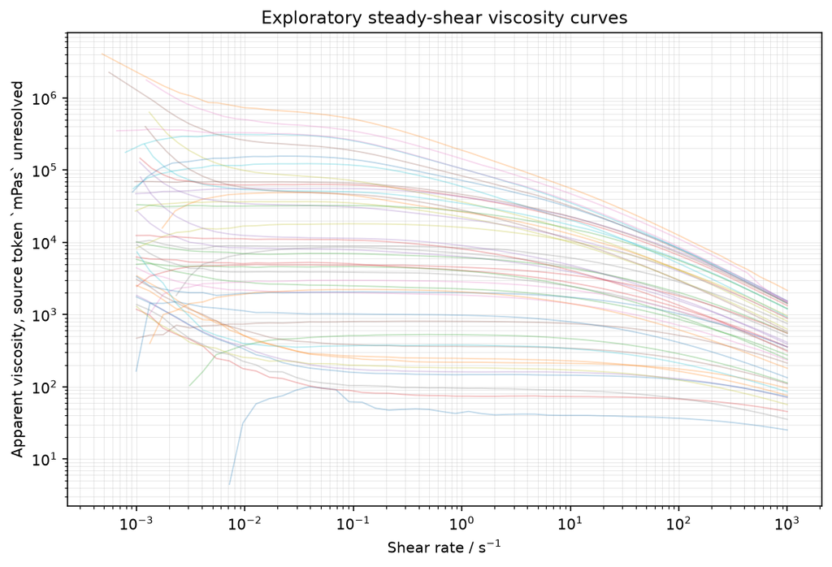

```
Preview: phase5_moduli_vs_strain_loglog.png
```

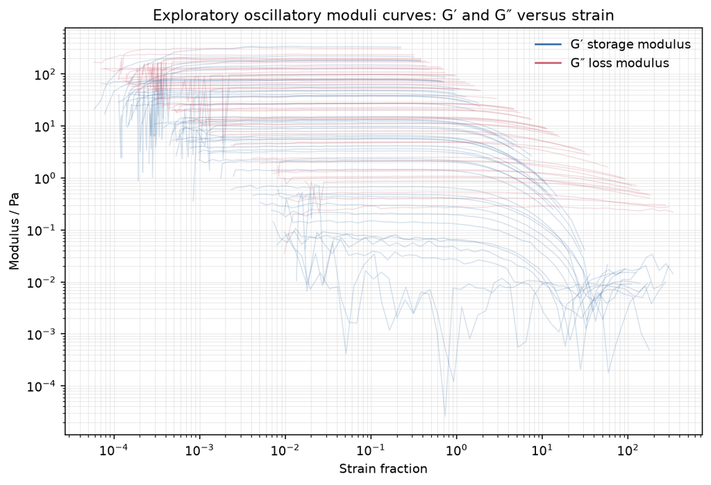

```
Preview: phase5_measurement_field_completeness_heatmap.png
```

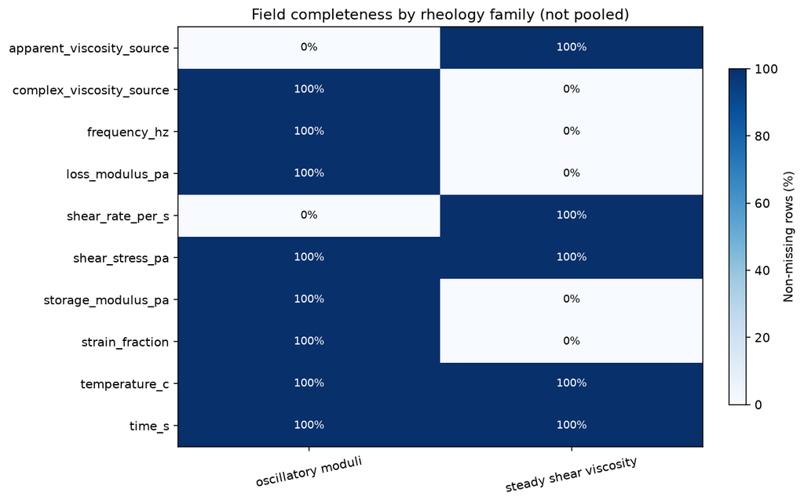

```
Preview: phase5_image_shape_intensity_heatmap.png
```

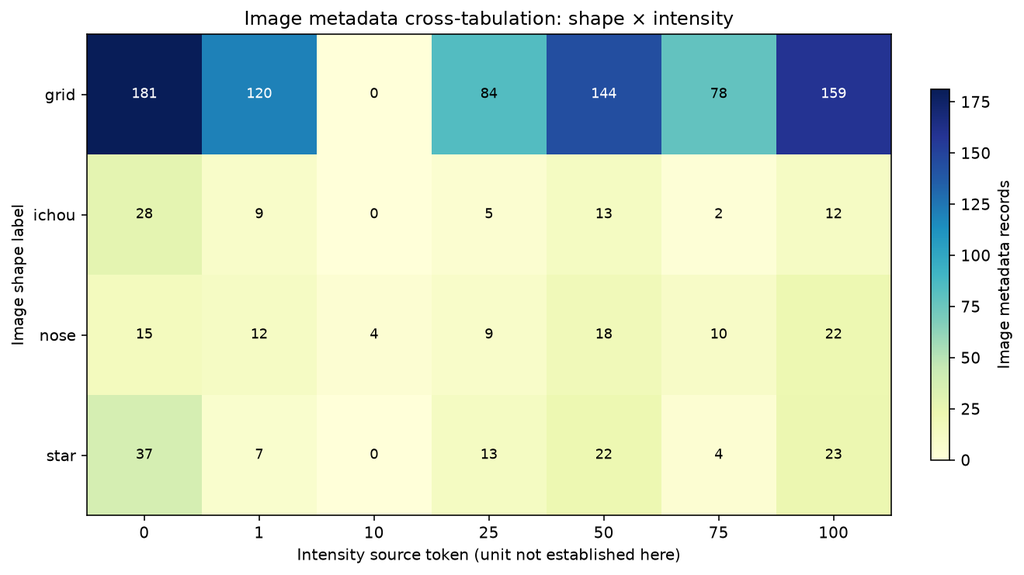

```
[2026-10-10 01:36:29 UTC] PREVIEWS FINISHED: all figures are saved; offline gallery ready
Phase 5 outputs written to: C:\Users\sufer\Documents\hydrogel-bioink\data\processed\hydrogel_rheology_and_printing_context_analysis
Critical validation failures: 0
```

|  | check | status | severity | evidence |
| --- | --- | --- | --- | --- |
| 66 | Phase 5 figure exists: figures/phase5_image_intensity_distribution.png | PASS | WARNING | {"path": "data/processed/hydrogel_rheology_and_printing_context_analysis/figures/phase5_image_intensity_distribution... |
| 67 | Phase 5 figure exists: figures/phase5_worksheet_point_counts.png | PASS | WARNING | {"path": "data/processed/hydrogel_rheology_and_printing_context_analysis/figures/phase5_worksheet_point_counts.png",... |
| 68 | Phase 5 figure exists: figures/phase5_measurement_field_completeness_heatmap.png | PASS | WARNING | {"path": "data/processed/hydrogel_rheology_and_printing_context_analysis/figures/phase5_measurement_field_completene... |
| 69 | Phase 5 figure exists: figures/phase5_viscosity_quality_and_exclusion_counts.png | PASS | WARNING | {"path": "data/processed/hydrogel_rheology_and_printing_context_analysis/figures/phase5_viscosity_quality_and_exclus... |
| 70 | Phase 5 figure exists: figures/phase5_viscosity_slope_distribution_and_coverage.png | PASS | WARNING | {"path": "data/processed/hydrogel_rheology_and_printing_context_analysis/figures/phase5_viscosity_slope_distribution... |
| 71 | Phase 5 figure exists: figures/phase5_viscosity_example_curve_small_multiples.png | PASS | WARNING | {"path": "data/processed/hydrogel_rheology_and_printing_context_analysis/figures/phase5_viscosity_example_curve_smal... |
| 72 | Phase 5 figure exists: figures/phase5_shear_stress_vs_shear_rate.png | PASS | WARNING | {"path": "data/processed/hydrogel_rheology_and_printing_context_analysis/figures/phase5_shear_stress_vs_shear_rate.p... |
| 73 | Phase 5 figure exists: figures/phase5_storage_vs_loss_modulus_scatter.png | PASS | WARNING | {"path": "data/processed/hydrogel_rheology_and_printing_context_analysis/figures/phase5_storage_vs_loss_modulus_scat... |
| 74 | Phase 5 figure exists: figures/phase5_modulus_balance_counts.png | PASS | WARNING | {"path": "data/processed/hydrogel_rheology_and_printing_context_analysis/figures/phase5_modulus_balance_counts.png",... |
| 75 | Phase 5 figure exists: figures/phase5_tan_delta_worksheet_medians.png | PASS | WARNING | {"path": "data/processed/hydrogel_rheology_and_printing_context_analysis/figures/phase5_tan_delta_worksheet_medians.... |
| 76 | Phase 5 figure exists: figures/phase5_oscillatory_example_curve_small_multiples.png | PASS | WARNING | {"path": "data/processed/hydrogel_rheology_and_printing_context_analysis/figures/phase5_oscillatory_example_curve_sm... |
| 77 | Phase 5 figure exists: figures/phase5_qc_flag_rate_by_family.png | PASS | WARNING | {"path": "data/processed/hydrogel_rheology_and_printing_context_analysis/figures/phase5_qc_flag_rate_by_family.png",... |
| 78 | Phase 5 figure exists: figures/phase5_filename_linkage_status_counts.png | PASS | WARNING | {"path": "data/processed/hydrogel_rheology_and_printing_context_analysis/figures/phase5_filename_linkage_status_coun... |
| 79 | Phase 5 figure exists: figures/phase5_data_hierarchy_counts.png | PASS | WARNING | {"path": "data/processed/hydrogel_rheology_and_printing_context_analysis/figures/phase5_data_hierarchy_counts.png", ... |
| 80 | Phase 5 figure exists: figures/phase5_candidate_label_presence_counts.png | PASS | WARNING | {"path": "data/processed/hydrogel_rheology_and_printing_context_analysis/figures/phase5_candidate_label_presence_cou... |
| 81 | Phase 5 figure exists: figures/phase5_image_ink_type_top15.png | PASS | WARNING | {"path": "data/processed/hydrogel_rheology_and_printing_context_analysis/figures/phase5_image_ink_type_top15.png", "... |
| 82 | Phase 5 figure exists: figures/phase5_image_shape_intensity_heatmap.png | PASS | WARNING | {"path": "data/processed/hydrogel_rheology_and_printing_context_analysis/figures/phase5_image_shape_intensity_heatma... |
| 83 | Phase 5 figure exists: figures/phase5_image_metadata_missingness_stacked.png | PASS | WARNING | {"path": "data/processed/hydrogel_rheology_and_printing_context_analysis/figures/phase5_image_metadata_missingness_s... |
| 84 | Phase 5 figure exists: figures/phase5_image_metadata_date_coverage.png | PASS | WARNING | {"path": "data/processed/hydrogel_rheology_and_printing_context_analysis/figures/phase5_image_metadata_date_coverage... |
| 85 | Phase 5 run manifest exists | PASS | CRITICAL | {"path": "C:\\Users\\sufer\\Documents\\hydrogel-bioink\\data\\processed\\hydrogel_rheology_and_printing_context_anal... |

```
[2026-10-10 01:36:29 UTC] SECTION FINISHED: manifest and validation ledger
```

```python
# Small inline preview selection for immediate feedback; other figures available
# in phase5_figure_gallery.html (open in a browser next to the figures folder).
phase5_progress('PREVIEWS START: four selected figures')
for preview in [
    'phase5_viscosity_vs_shear_rate_loglog.png',
    'phase5_moduli_vs_strain_loglog.png',
    'phase5_measurement_field_completeness_heatmap.png',
    'phase5_image_shape_intensity_heatmap.png'
]:
    picture=FIGURE_DIR / preview
    if picture.is_file():
        print('Preview:',preview,flush=True)
        display(Image(filename=str(picture),width=520))
phase5_progress('PREVIEWS FINISHED: all figures are saved; offline gallery ready')
print("Phase 5 outputs written to:", PHASE5_DIR)
print("Critical validation failures:", critical_failures)
display(phase5_validation.tail(20))

if critical_failures:
    raise RuntimeError("Critical Phase 5 validation failures were recorded.")

phase5_progress("SECTION FINISHED: manifest and validation ledger")
```